# **PR 1 - Breast Cancer Classification With Neural Networks**

## Import Libraries

```python
import numpy as np
import pandas as pd
import matplotlib.pyplot as plt
import seaborn as sns
import os
os.makedirs('plots', exist_ok=True)
import warnings
warnings.filterwarnings("ignore")
```

## Task 1 Load Dataset

```python
from sklearn.datasets import load_breast_cancer
df = load_breast_cancer(as_frame=True)
x = df.data
y = df.target
```

```python
x.shape
```

```
(569, 30)
```

```python
x.describe().round(2)
```

|  | mean radius | mean texture | mean perimeter | mean area | mean smoothness | mean compactness | mean concavity | mean concave points | mean symmetry | mean fractal dimension | ... | worst radius | worst texture | worst perimeter | worst area | worst smoothness | worst compactness | worst concavity | worst concave points | worst symmetry | worst fractal dimension |
| --- | --- | --- | --- | --- | --- | --- | --- | --- | --- | --- | --- | --- | --- | --- | --- | --- | --- | --- | --- | --- | --- |
| count | 569.00 | 569.00 | 569.00 | 569.00 | 569.00 | 569.00 | 569.00 | 569.00 | 569.00 | 569.00 | ... | 569.00 | 569.00 | 569.00 | 569.00 | 569.00 | 569.00 | 569.00 | 569.00 | 569.00 | 569.00 |
| mean | 14.13 | 19.29 | 91.97 | 654.89 | 0.10 | 0.10 | 0.09 | 0.05 | 0.18 | 0.06 | ... | 16.27 | 25.68 | 107.26 | 880.58 | 0.13 | 0.25 | 0.27 | 0.11 | 0.29 | 0.08 |
| std | 3.52 | 4.30 | 24.30 | 351.91 | 0.01 | 0.05 | 0.08 | 0.04 | 0.03 | 0.01 | ... | 4.83 | 6.15 | 33.60 | 569.36 | 0.02 | 0.16 | 0.21 | 0.07 | 0.06 | 0.02 |
| min | 6.98 | 9.71 | 43.79 | 143.50 | 0.05 | 0.02 | 0.00 | 0.00 | 0.11 | 0.05 | ... | 7.93 | 12.02 | 50.41 | 185.20 | 0.07 | 0.03 | 0.00 | 0.00 | 0.16 | 0.06 |
| 25% | 11.70 | 16.17 | 75.17 | 420.30 | 0.09 | 0.06 | 0.03 | 0.02 | 0.16 | 0.06 | ... | 13.01 | 21.08 | 84.11 | 515.30 | 0.12 | 0.15 | 0.11 | 0.06 | 0.25 | 0.07 |
| 50% | 13.37 | 18.84 | 86.24 | 551.10 | 0.10 | 0.09 | 0.06 | 0.03 | 0.18 | 0.06 | ... | 14.97 | 25.41 | 97.66 | 686.50 | 0.13 | 0.21 | 0.23 | 0.10 | 0.28 | 0.08 |
| 75% | 15.78 | 21.80 | 104.10 | 782.70 | 0.11 | 0.13 | 0.13 | 0.07 | 0.20 | 0.07 | ... | 18.79 | 29.72 | 125.40 | 1084.00 | 0.15 | 0.34 | 0.38 | 0.16 | 0.32 | 0.09 |
| max | 28.11 | 39.28 | 188.50 | 2501.00 | 0.16 | 0.35 | 0.43 | 0.20 | 0.30 | 0.10 | ... | 36.04 | 49.54 | 251.20 | 4254.00 | 0.22 | 1.06 | 1.25 | 0.29 | 0.66 | 0.21 |

8 rows × 30 columns

## Exploratory Data Analysis (EDA)

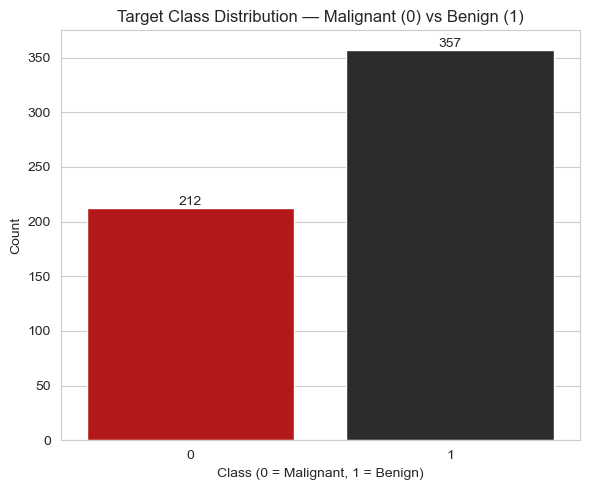

```python
plt.figure(figsize=(6, 5))
sns.set_style('whitegrid')
ax = sns.countplot(x=y, hue=y, palette=['#CC0000', '#2C2C2C'], legend=False)
ax.set_title('Target Class Distribution — Malignant (0) vs Benign (1)')
ax.set_xlabel('Class (0 = Malignant, 1 = Benign)')
ax.set_ylabel('Count')

for p in ax.patches:
    count = int(p.get_height())
    ax.annotate(str(count), (p.get_x() + p.get_width() / 2, p.get_height()),
                ha='center', va='bottom')

plt.tight_layout()
plt.savefig('plots/class_distribution.png')
plt.show()
```

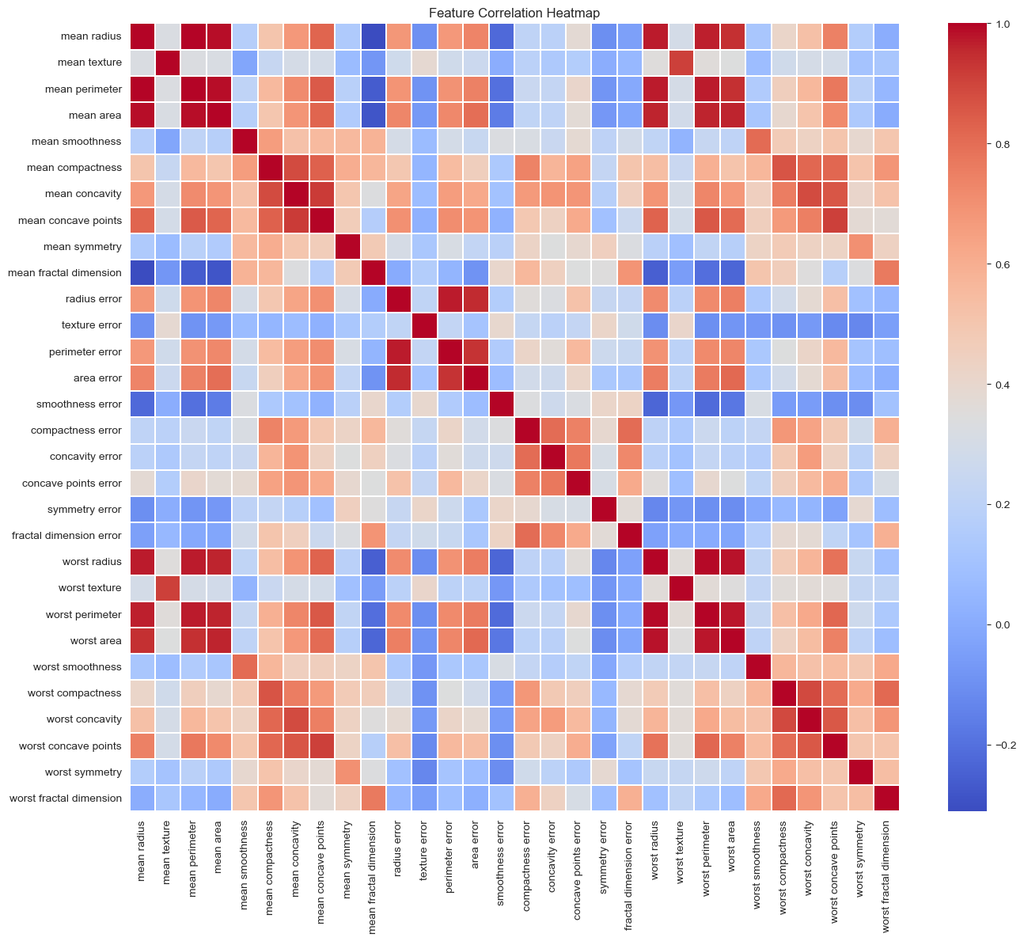

```python
corr_matrix = x.corr()
plt.figure(figsize=(14, 12))
sns.heatmap(corr_matrix, annot=False, cmap='coolwarm', linewidths=0.3)
plt.title('Feature Correlation Heatmap')
plt.tight_layout()
plt.savefig('plots/correlation_heatmap.png')
plt.show()
```

```python
from sklearn.model_selection import train_test_split
from sklearn.preprocessing import StandardScaler
from sklearn.metrics import classification_report, confusion_matrix, precision_score, recall_score, f1_score, accuracy_score

import tensorflow
from tensorflow import keras
from tensorflow.keras.models import Sequential
from tensorflow.keras.layers import Dense, Dropout
from tensorflow.keras import regularizers
```

```python
x_train,x_test,y_train,y_test = train_test_split(x,y,test_size = 0.2,random_state=42,stratify=y)
```

```python
scaler = StandardScaler()
scaler.fit(x_train)
x_train_sc = scaler.transform(x_train)
x_test_sc = scaler.transform(x_test)
```

### - Why scaling for neural networks

Neural networks are trained using gradient based optimizers such as SGD and Adam. These optimizers update the model weights step by step based on the size of the gradients.

If some features have a very different scale than others (for example, one feature ranges from 0 to 1000 and another ranges from 0 to 1), the features with a large range can dominate the early updates, while features with a small range have very little influence on learning. This makes training slower and less stable, and the optimizer can struggle to find a good solution.

StandardScaler transforms every feature so that it has a mean of 0 and a standard deviation of 1. This puts all features on a similar scale, which helps the neural network learn more efficiently and converge faster.

## Task 2 Single Layer Preceptron (SLP)

```python
model_slp = Sequential()
model_slp.add(Dense(1, activation='sigmoid',input_dim = 30))
model_slp.summary()
```

```
Model: "sequential"
```

```
┏━━━━━━━━━━━━━━━━━━━━━━━━━━━━━━━━━━━━━━┳━━━━━━━━━━━━━━━━━━━━━━━━━━━━━┳━━━━━━━━━━━━━━━━━┓
┃ Layer (type)                         ┃ Output Shape                ┃         Param # ┃
┡━━━━━━━━━━━━━━━━━━━━━━━━━━━━━━━━━━━━━━╇━━━━━━━━━━━━━━━━━━━━━━━━━━━━━╇━━━━━━━━━━━━━━━━━┩
│ dense (Dense)                        │ (None, 1)                   │              31 │
└──────────────────────────────────────┴─────────────────────────────┴─────────────────┘
```

```
 Total params: 31 (124.00 B)
```

```
 Trainable params: 31 (124.00 B)
```

```
 Non-trainable params: 0 (0.00 B)
```

```python
model_slp.compile(optimizer = 'adam', loss = 'binary_crossentropy', metrics = ['accuracy'])
total_params = model_slp.count_params()
total_params
```

```
WARNING:tensorflow:TensorFlow GPU support is not available on native Windows for TensorFlow >= 2.11. Even if CUDA/cuDNN are installed, GPU will not be used. Please use WSL2 or the TensorFlow-DirectML plugin.
```

```
31
```

```python
history_slp = model_slp.fit(x_train_sc,y_train,epochs = 50, batch_size = 32, validation_split = 0.1, verbose = 1)
```

```
13/13 ━━━━━━━━━━━━━━━━━━━━ 2s 32ms/step - accuracy: 0.6699 - loss: 0.6365 - val_accuracy: 0.5652 - val_loss: 0.6917
13/13 ━━━━━━━━━━━━━━━━━━━━ 0s 15ms/step - accuracy: 0.7262 - loss: 0.5739 - val_accuracy: 0.6304 - val_loss: 0.6354
13/13 ━━━━━━━━━━━━━━━━━━━━ 0s 13ms/step - accuracy: 0.7628 - loss: 0.5212 - val_accuracy: 0.6739 - val_loss: 0.5874
13/13 ━━━━━━━━━━━━━━━━━━━━ 0s 16ms/step - accuracy: 0.7848 - loss: 0.4771 - val_accuracy: 0.7174 - val_loss: 0.5466
13/13 ━━━━━━━━━━━━━━━━━━━━ 0s 13ms/step - accuracy: 0.8240 - loss: 0.4402 - val_accuracy: 0.7174 - val_loss: 0.5119
13/13 ━━━━━━━━━━━━━━━━━━━━ 0s 14ms/step - accuracy: 0.8509 - loss: 0.4084 - val_accuracy: 0.7391 - val_loss: 0.4836
13/13 ━━━━━━━━━━━━━━━━━━━━ 0s 14ms/step - accuracy: 0.8704 - loss: 0.3814 - val_accuracy: 0.7609 - val_loss: 0.4569
13/13 ━━━━━━━━━━━━━━━━━━━━ 0s 13ms/step - accuracy: 0.8826 - loss: 0.3577 - val_accuracy: 0.7826 - val_loss: 0.4351
13/13 ━━━━━━━━━━━━━━━━━━━━ 0s 21ms/step - accuracy: 0.8998 - loss: 0.3375 - val_accuracy: 0.8043 - val_loss: 0.4144
13/13 ━━━━━━━━━━━━━━━━━━━━ 0s 17ms/step - accuracy: 0.9046 - loss: 0.3197 - val_accuracy: 0.8043 - val_loss: 0.3968
13/13 ━━━━━━━━━━━━━━━━━━━━ 0s 18ms/step - accuracy: 0.9095 - loss: 0.3035 - val_accuracy: 0.8043 - val_loss: 0.3806
13/13 ━━━━━━━━━━━━━━━━━━━━ 0s 19ms/step - accuracy: 0.9169 - loss: 0.2891 - val_accuracy: 0.8043 - val_loss: 0.3666
13/13 ━━━━━━━━━━━━━━━━━━━━ 0s 16ms/step - accuracy: 0.9218 - loss: 0.2766 - val_accuracy: 0.8478 - val_loss: 0.3523
13/13 ━━━━━━━━━━━━━━━━━━━━ 0s 16ms/step - accuracy: 0.9242 - loss: 0.2650 - val_accuracy: 0.8478 - val_loss: 0.3397
13/13 ━━━━━━━━━━━━━━━━━━━━ 0s 16ms/step - accuracy: 0.9242 - loss: 0.2543 - val_accuracy: 0.8696 - val_loss: 0.3288
13/13 ━━━━━━━━━━━━━━━━━━━━ 0s 18ms/step - accuracy: 0.9242 - loss: 0.2446 - val_accuracy: 0.8696 - val_loss: 0.3185
13/13 ━━━━━━━━━━━━━━━━━━━━ 1s 31ms/step - accuracy: 0.9242 - loss: 0.2360 - val_accuracy: 0.8696 - val_loss: 0.3091
13/13 ━━━━━━━━━━━━━━━━━━━━ 1s 13ms/step - accuracy: 0.9242 - loss: 0.2277 - val_accuracy: 0.8696 - val_loss: 0.3006
13/13 ━━━━━━━━━━━━━━━━━━━━ 0s 13ms/step - accuracy: 0.9267 - loss: 0.2205 - val_accuracy: 0.8696 - val_loss: 0.2917
13/13 ━━━━━━━━━━━━━━━━━━━━ 0s 13ms/step - accuracy: 0.9340 - loss: 0.2133 - val_accuracy: 0.8696 - val_loss: 0.2845
13/13 ━━━━━━━━━━━━━━━━━━━━ 0s 14ms/step - accuracy: 0.9389 - loss: 0.2072 - val_accuracy: 0.8696 - val_loss: 0.2768
13/13 ━━━━━━━━━━━━━━━━━━━━ 0s 15ms/step - accuracy: 0.9413 - loss: 0.2010 - val_accuracy: 0.8696 - val_loss: 0.2704
13/13 ━━━━━━━━━━━━━━━━━━━━ 0s 14ms/step - accuracy: 0.9413 - loss: 0.1954 - val_accuracy: 0.8696 - val_loss: 0.2645
13/13 ━━━━━━━━━━━━━━━━━━━━ 0s 14ms/step - accuracy: 0.9413 - loss: 0.1904 - val_accuracy: 0.8696 - val_loss: 0.2583
13/13 ━━━━━━━━━━━━━━━━━━━━ 0s 17ms/step - accuracy: 0.9413 - loss: 0.1853 - val_accuracy: 0.8913 - val_loss: 0.2525
13/13 ━━━━━━━━━━━━━━━━━━━━ 0s 15ms/step - accuracy: 0.9413 - loss: 0.1808 - val_accuracy: 0.8913 - val_loss: 0.2472
13/13 ━━━━━━━━━━━━━━━━━━━━ 0s 17ms/step - accuracy: 0.9413 - loss: 0.1765 - val_accuracy: 0.8913 - val_loss: 0.2426
13/13 ━━━━━━━━━━━━━━━━━━━━ 0s 12ms/step - accuracy: 0.9438 - loss: 0.1725 - val_accuracy: 0.8913 - val_loss: 0.2375
13/13 ━━━━━━━━━━━━━━━━━━━━ 0s 11ms/step - accuracy: 0.9462 - loss: 0.1686 - val_accuracy: 0.8913 - val_loss: 0.2332
13/13 ━━━━━━━━━━━━━━━━━━━━ 0s 12ms/step - accuracy: 0.9487 - loss: 0.1651 - val_accuracy: 0.8913 - val_loss: 0.2291
13/13 ━━━━━━━━━━━━━━━━━━━━ 0s 11ms/step - accuracy: 0.9511 - loss: 0.1617 - val_accuracy: 0.8913 - val_loss: 0.2251
13/13 ━━━━━━━━━━━━━━━━━━━━ 0s 11ms/step - accuracy: 0.9511 - loss: 0.1585 - val_accuracy: 0.8913 - val_loss: 0.2214
13/13 ━━━━━━━━━━━━━━━━━━━━ 0s 11ms/step - accuracy: 0.9511 - loss: 0.1555 - val_accuracy: 0.8913 - val_loss: 0.2182
13/13 ━━━━━━━━━━━━━━━━━━━━ 0s 11ms/step - accuracy: 0.9511 - loss: 0.1526 - val_accuracy: 0.8913 - val_loss: 0.2143
13/13 ━━━━━━━━━━━━━━━━━━━━ 0s 11ms/step - accuracy: 0.9535 - loss: 0.1499 - val_accuracy: 0.9130 - val_loss: 0.2110
13/13 ━━━━━━━━━━━━━━━━━━━━ 0s 11ms/step - accuracy: 0.9584 - loss: 0.1472 - val_accuracy: 0.9130 - val_loss: 0.2078
13/13 ━━━━━━━━━━━━━━━━━━━━ 0s 10ms/step - accuracy: 0.9584 - loss: 0.1448 - val_accuracy: 0.9130 - val_loss: 0.2048
13/13 ━━━━━━━━━━━━━━━━━━━━ 0s 11ms/step - accuracy: 0.9584 - loss: 0.1425 - val_accuracy: 0.9130 - val_loss: 0.2021
13/13 ━━━━━━━━━━━━━━━━━━━━ 0s 10ms/step - accuracy: 0.9584 - loss: 0.1402 - val_accuracy: 0.9130 - val_loss: 0.1994
13/13 ━━━━━━━━━━━━━━━━━━━━ 0s 11ms/step - accuracy: 0.9584 - loss: 0.1381 - val_accuracy: 0.9348 - val_loss: 0.1965
13/13 ━━━━━━━━━━━━━━━━━━━━ 0s 11ms/step - accuracy: 0.9584 - loss: 0.1360 - val_accuracy: 0.9348 - val_loss: 0.1943
13/13 ━━━━━━━━━━━━━━━━━━━━ 0s 11ms/step - accuracy: 0.9609 - loss: 0.1341 - val_accuracy: 0.9348 - val_loss: 0.1919
13/13 ━━━━━━━━━━━━━━━━━━━━ 0s 12ms/step - accuracy: 0.9609 - loss: 0.1322 - val_accuracy: 0.9348 - val_loss: 0.1896
13/13 ━━━━━━━━━━━━━━━━━━━━ 0s 15ms/step - accuracy: 0.9633 - loss: 0.1304 - val_accuracy: 0.9348 - val_loss: 0.1875
13/13 ━━━━━━━━━━━━━━━━━━━━ 0s 11ms/step - accuracy: 0.9633 - loss: 0.1287 - val_accuracy: 0.9348 - val_loss: 0.1857
13/13 ━━━━━━━━━━━━━━━━━━━━ 0s 11ms/step - accuracy: 0.9658 - loss: 0.1270 - val_accuracy: 0.9348 - val_loss: 0.1834
13/13 ━━━━━━━━━━━━━━━━━━━━ 0s 11ms/step - accuracy: 0.9658 - loss: 0.1255 - val_accuracy: 0.9348 - val_loss: 0.1811
13/13 ━━━━━━━━━━━━━━━━━━━━ 0s 11ms/step - accuracy: 0.9658 - loss: 0.1239 - val_accuracy: 0.9348 - val_loss: 0.1793
13/13 ━━━━━━━━━━━━━━━━━━━━ 0s 11ms/step - accuracy: 0.9658 - loss: 0.1225 - val_accuracy: 0.9348 - val_loss: 0.1776
13/13 ━━━━━━━━━━━━━━━━━━━━ 0s 11ms/step - accuracy: 0.9658 - loss: 0.1210 - val_accuracy: 0.9348 - val_loss: 0.1757
```

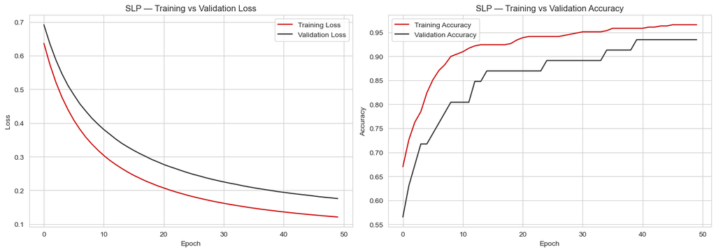

```python
fig, axes = plt.subplots(1, 2, figsize=(14, 5))
axes[0].plot(history_slp.history['loss'], label='Training Loss', color='#CC0000')
axes[0].plot(history_slp.history['val_loss'], label='Validation Loss', color='#2C2C2C')
axes[0].set_title('SLP — Training vs Validation Loss')
axes[0].set_xlabel('Epoch')
axes[0].set_ylabel('Loss')
axes[0].legend()
axes[1].plot(history_slp.history['accuracy'], label='Training Accuracy', color='#CC0000')
axes[1].plot(history_slp.history['val_accuracy'], label='Validation Accuracy', color='#2C2C2C')
axes[1].set_title('SLP — Training vs Validation Accuracy')
axes[1].set_xlabel('Epoch')
axes[1].set_ylabel('Accuracy')
axes[1].legend()
plt.tight_layout()
plt.savefig('plots/slp_training_curves.png')
plt.show()
```

```python
slp_loss,slp_acc = model_slp.evaluate(x_test_sc,y_test,verbose=0)
slp_loss
```

```
0.15584410727024078
```

```python
y_pred_slp = (model_slp.predict(x_test_sc)>0.5).astype(int)
print(classification_report(y_test,y_pred_slp))
```

```
4/4 ━━━━━━━━━━━━━━━━━━━━ 0s 21ms/step
              precision    recall  f1-score   support

           0       0.90      0.90      0.90        42
           1       0.94      0.94      0.94        72

    accuracy                           0.93       114
   macro avg       0.92      0.92      0.92       114
weighted avg       0.93      0.93      0.93       114
```

```python
slp_precision = precision_score(y_test, y_pred_slp)
slp_recall = recall_score(y_test, y_pred_slp)
slp_f1 = f1_score(y_test, y_pred_slp)

results = {}
results['SLP'] = {
    'Architecture': 'Dense(1, sigmoid)',
    'Regularization': 'None',
    'Dropout Rate': 'None',
    'Early Stopping': 'No',
    'Test Accuracy': slp_acc,
    'Test Precision': slp_precision,
    'Test Recall': slp_recall,
    'Test F1-Score': slp_f1
}
results['SLP']
```

```
{'Architecture': 'Dense(1, sigmoid)',
 'Regularization': 'None',
 'Dropout Rate': 'None',
 'Early Stopping': 'No',
 'Test Accuracy': 0.9298245906829834,
 'Test Precision': 0.9444444444444444,
 'Test Recall': 0.9444444444444444,
 'Test F1-Score': 0.9444444444444444}
```

## Task 3 Multi-Layer Perceptron (MLP)

```python
model_mlp = Sequential()
model_mlp.add(Dense(64, activation='relu',input_dim = 30))
model_mlp.add(Dense(32, activation='relu'))
model_mlp.add(Dense(1, activation='sigmoid'))
model_mlp.summary()
```

```
Model: "sequential_1"
```

```
┏━━━━━━━━━━━━━━━━━━━━━━━━━━━━━━━━━━━━━━┳━━━━━━━━━━━━━━━━━━━━━━━━━━━━━┳━━━━━━━━━━━━━━━━━┓
┃ Layer (type)                         ┃ Output Shape                ┃         Param # ┃
┡━━━━━━━━━━━━━━━━━━━━━━━━━━━━━━━━━━━━━━╇━━━━━━━━━━━━━━━━━━━━━━━━━━━━━╇━━━━━━━━━━━━━━━━━┩
│ dense_1 (Dense)                      │ (None, 64)                  │           1,984 │
├──────────────────────────────────────┼─────────────────────────────┼─────────────────┤
│ dense_2 (Dense)                      │ (None, 32)                  │           2,080 │
├──────────────────────────────────────┼─────────────────────────────┼─────────────────┤
│ dense_3 (Dense)                      │ (None, 1)                   │              33 │
└──────────────────────────────────────┴─────────────────────────────┴─────────────────┘
```

```
 Total params: 4,097 (16.00 KB)
```

```
 Trainable params: 4,097 (16.00 KB)
```

```
 Non-trainable params: 0 (0.00 B)
```

Hidden layers allow the model to learn non-linear relationships in the data, which a single layer cannot do. Each Dense layer transforms the input into a new representation. When we stack multiple hidden layers, the network can combine simple patterns from earlier layers into more complex patterns in later layers. The ReLU activation function adds non-linearity between layers, which helps the network learn non-linear relationships instead of just a straight line boundary.

```python
model_mlp.compile(optimizer = 'adam', loss = 'binary_crossentropy', metrics = ['accuracy'])
history_mlp = model_mlp.fit(x_train_sc,y_train,epochs = 100, batch_size = 32, validation_split = 0.1, verbose = 1)
```

```
13/13 ━━━━━━━━━━━━━━━━━━━━ 2s 32ms/step - accuracy: 0.7139 - loss: 0.5708 - val_accuracy: 0.8478 - val_loss: 0.4425
13/13 ━━━━━━━━━━━━━━━━━━━━ 0s 11ms/step - accuracy: 0.9340 - loss: 0.3117 - val_accuracy: 0.9348 - val_loss: 0.3008
13/13 ━━━━━━━━━━━━━━━━━━━━ 0s 11ms/step - accuracy: 0.9535 - loss: 0.2048 - val_accuracy: 0.9348 - val_loss: 0.2277
13/13 ━━━━━━━━━━━━━━━━━━━━ 0s 11ms/step - accuracy: 0.9609 - loss: 0.1455 - val_accuracy: 0.9565 - val_loss: 0.1801
13/13 ━━━━━━━━━━━━━━━━━━━━ 0s 11ms/step - accuracy: 0.9682 - loss: 0.1134 - val_accuracy: 0.9565 - val_loss: 0.1499
13/13 ━━━━━━━━━━━━━━━━━━━━ 0s 11ms/step - accuracy: 0.9756 - loss: 0.0945 - val_accuracy: 0.9783 - val_loss: 0.1243
13/13 ━━━━━━━━━━━━━━━━━━━━ 0s 11ms/step - accuracy: 0.9756 - loss: 0.0815 - val_accuracy: 0.9783 - val_loss: 0.1071
13/13 ━━━━━━━━━━━━━━━━━━━━ 0s 11ms/step - accuracy: 0.9829 - loss: 0.0722 - val_accuracy: 0.9783 - val_loss: 0.0946
13/13 ━━━━━━━━━━━━━━━━━━━━ 0s 11ms/step - accuracy: 0.9853 - loss: 0.0651 - val_accuracy: 0.9783 - val_loss: 0.0855
13/13 ━━━━━━━━━━━━━━━━━━━━ 0s 11ms/step - accuracy: 0.9878 - loss: 0.0594 - val_accuracy: 0.9783 - val_loss: 0.0800
13/13 ━━━━━━━━━━━━━━━━━━━━ 0s 11ms/step - accuracy: 0.9878 - loss: 0.0549 - val_accuracy: 0.9565 - val_loss: 0.0753
13/13 ━━━━━━━━━━━━━━━━━━━━ 0s 11ms/step - accuracy: 0.9878 - loss: 0.0509 - val_accuracy: 0.9783 - val_loss: 0.0737
13/13 ━━━━━━━━━━━━━━━━━━━━ 0s 11ms/step - accuracy: 0.9878 - loss: 0.0471 - val_accuracy: 0.9565 - val_loss: 0.0718
13/13 ━━━━━━━━━━━━━━━━━━━━ 0s 11ms/step - accuracy: 0.9902 - loss: 0.0440 - val_accuracy: 0.9565 - val_loss: 0.0703
13/13 ━━━━━━━━━━━━━━━━━━━━ 0s 15ms/step - accuracy: 0.9902 - loss: 0.0408 - val_accuracy: 0.9565 - val_loss: 0.0680
13/13 ━━━━━━━━━━━━━━━━━━━━ 0s 11ms/step - accuracy: 0.9902 - loss: 0.0385 - val_accuracy: 0.9565 - val_loss: 0.0679
13/13 ━━━━━━━━━━━━━━━━━━━━ 0s 11ms/step - accuracy: 0.9902 - loss: 0.0359 - val_accuracy: 0.9565 - val_loss: 0.0672
13/13 ━━━━━━━━━━━━━━━━━━━━ 0s 11ms/step - accuracy: 0.9902 - loss: 0.0336 - val_accuracy: 0.9565 - val_loss: 0.0693
13/13 ━━━━━━━━━━━━━━━━━━━━ 0s 11ms/step - accuracy: 0.9902 - loss: 0.0316 - val_accuracy: 0.9565 - val_loss: 0.0705
13/13 ━━━━━━━━━━━━━━━━━━━━ 0s 12ms/step - accuracy: 0.9902 - loss: 0.0289 - val_accuracy: 0.9565 - val_loss: 0.0676
13/13 ━━━━━━━━━━━━━━━━━━━━ 0s 11ms/step - accuracy: 0.9902 - loss: 0.0272 - val_accuracy: 0.9565 - val_loss: 0.0678
13/13 ━━━━━━━━━━━━━━━━━━━━ 0s 11ms/step - accuracy: 0.9927 - loss: 0.0256 - val_accuracy: 0.9565 - val_loss: 0.0679
13/13 ━━━━━━━━━━━━━━━━━━━━ 0s 14ms/step - accuracy: 0.9927 - loss: 0.0242 - val_accuracy: 0.9565 - val_loss: 0.0651
13/13 ━━━━━━━━━━━━━━━━━━━━ 0s 12ms/step - accuracy: 0.9927 - loss: 0.0226 - val_accuracy: 0.9565 - val_loss: 0.0648
13/13 ━━━━━━━━━━━━━━━━━━━━ 0s 14ms/step - accuracy: 0.9927 - loss: 0.0213 - val_accuracy: 0.9565 - val_loss: 0.0674
13/13 ━━━━━━━━━━━━━━━━━━━━ 0s 13ms/step - accuracy: 0.9927 - loss: 0.0206 - val_accuracy: 0.9565 - val_loss: 0.0673
13/13 ━━━━━━━━━━━━━━━━━━━━ 0s 14ms/step - accuracy: 0.9927 - loss: 0.0202 - val_accuracy: 0.9783 - val_loss: 0.0674
13/13 ━━━━━━━━━━━━━━━━━━━━ 0s 14ms/step - accuracy: 0.9951 - loss: 0.0182 - val_accuracy: 0.9565 - val_loss: 0.0671
13/13 ━━━━━━━━━━━━━━━━━━━━ 0s 12ms/step - accuracy: 0.9951 - loss: 0.0167 - val_accuracy: 0.9565 - val_loss: 0.0651
13/13 ━━━━━━━━━━━━━━━━━━━━ 0s 11ms/step - accuracy: 0.9951 - loss: 0.0156 - val_accuracy: 0.9565 - val_loss: 0.0644
13/13 ━━━━━━━━━━━━━━━━━━━━ 0s 11ms/step - accuracy: 0.9951 - loss: 0.0148 - val_accuracy: 0.9783 - val_loss: 0.0626
13/13 ━━━━━━━━━━━━━━━━━━━━ 0s 14ms/step - accuracy: 0.9976 - loss: 0.0138 - val_accuracy: 0.9783 - val_loss: 0.0617
13/13 ━━━━━━━━━━━━━━━━━━━━ 0s 14ms/step - accuracy: 0.9951 - loss: 0.0129 - val_accuracy: 0.9783 - val_loss: 0.0646
13/13 ━━━━━━━━━━━━━━━━━━━━ 0s 15ms/step - accuracy: 0.9951 - loss: 0.0126 - val_accuracy: 0.9565 - val_loss: 0.0656
13/13 ━━━━━━━━━━━━━━━━━━━━ 0s 13ms/step - accuracy: 0.9976 - loss: 0.0116 - val_accuracy: 0.9565 - val_loss: 0.0651
13/13 ━━━━━━━━━━━━━━━━━━━━ 0s 12ms/step - accuracy: 0.9976 - loss: 0.0110 - val_accuracy: 0.9565 - val_loss: 0.0652
13/13 ━━━━━━━━━━━━━━━━━━━━ 0s 14ms/step - accuracy: 0.9976 - loss: 0.0105 - val_accuracy: 0.9783 - val_loss: 0.0626
13/13 ━━━━━━━━━━━━━━━━━━━━ 0s 12ms/step - accuracy: 0.9976 - loss: 0.0096 - val_accuracy: 0.9565 - val_loss: 0.0640
13/13 ━━━━━━━━━━━━━━━━━━━━ 0s 11ms/step - accuracy: 0.9976 - loss: 0.0092 - val_accuracy: 0.9565 - val_loss: 0.0655
13/13 ━━━━━━━━━━━━━━━━━━━━ 0s 11ms/step - accuracy: 1.0000 - loss: 0.0088 - val_accuracy: 0.9565 - val_loss: 0.0674
```

[output cut: 45 more lines]

```
13/13 ━━━━━━━━━━━━━━━━━━━━ 0s 11ms/step - accuracy: 1.0000 - loss: 0.0012 - val_accuracy: 0.9565 - val_loss: 0.0844
13/13 ━━━━━━━━━━━━━━━━━━━━ 0s 12ms/step - accuracy: 1.0000 - loss: 0.0011 - val_accuracy: 0.9565 - val_loss: 0.0810
13/13 ━━━━━━━━━━━━━━━━━━━━ 0s 13ms/step - accuracy: 1.0000 - loss: 0.0011 - val_accuracy: 0.9565 - val_loss: 0.0802
13/13 ━━━━━━━━━━━━━━━━━━━━ 0s 14ms/step - accuracy: 1.0000 - loss: 0.0011 - val_accuracy: 0.9565 - val_loss: 0.0802
13/13 ━━━━━━━━━━━━━━━━━━━━ 0s 14ms/step - accuracy: 1.0000 - loss: 0.0010 - val_accuracy: 0.9565 - val_loss: 0.0827
13/13 ━━━━━━━━━━━━━━━━━━━━ 0s 26ms/step - accuracy: 1.0000 - loss: 9.9135e-04 - val_accuracy: 0.9565 - val_loss: 0.0813
13/13 ━━━━━━━━━━━━━━━━━━━━ 0s 18ms/step - accuracy: 1.0000 - loss: 9.7468e-04 - val_accuracy: 0.9565 - val_loss: 0.0802
13/13 ━━━━━━━━━━━━━━━━━━━━ 0s 13ms/step - accuracy: 1.0000 - loss: 9.2475e-04 - val_accuracy: 0.9565 - val_loss: 0.0842
13/13 ━━━━━━━━━━━━━━━━━━━━ 0s 14ms/step - accuracy: 1.0000 - loss: 9.2054e-04 - val_accuracy: 0.9565 - val_loss: 0.0817
13/13 ━━━━━━━━━━━━━━━━━━━━ 0s 14ms/step - accuracy: 1.0000 - loss: 8.7657e-04 - val_accuracy: 0.9565 - val_loss: 0.0809
13/13 ━━━━━━━━━━━━━━━━━━━━ 0s 17ms/step - accuracy: 1.0000 - loss: 9.0821e-04 - val_accuracy: 0.9565 - val_loss: 0.0802
13/13 ━━━━━━━━━━━━━━━━━━━━ 0s 18ms/step - accuracy: 1.0000 - loss: 7.9955e-04 - val_accuracy: 0.9565 - val_loss: 0.0856
13/13 ━━━━━━━━━━━━━━━━━━━━ 0s 17ms/step - accuracy: 1.0000 - loss: 8.1447e-04 - val_accuracy: 0.9565 - val_loss: 0.0867
13/13 ━━━━━━━━━━━━━━━━━━━━ 0s 18ms/step - accuracy: 1.0000 - loss: 8.0339e-04 - val_accuracy: 0.9565 - val_loss: 0.0833
13/13 ━━━━━━━━━━━━━━━━━━━━ 0s 17ms/step - accuracy: 1.0000 - loss: 7.6531e-04 - val_accuracy: 0.9565 - val_loss: 0.0855
```

```python
def build_mlp(activation):
    model = keras.Sequential([
        keras.Input(shape=(30,)),
        keras.layers.Dense(64, activation=activation),
        keras.layers.Dense(32, activation=activation),
        keras.layers.Dense(1, activation='sigmoid')
    ])
    model.compile(optimizer='adam', loss='binary_crossentropy', metrics=['accuracy'])
    return model
activations = ['relu', 'tanh', 'sigmoid']
activation_models = {}
activation_histories = {}
for act in activations:
    model = build_mlp(act)
    history = model.fit(
        x_train_sc,
        y_train,
        epochs=100,
        batch_size=32,
        validation_split=0.1,
        verbose=0
    )
    activation_models[act] = model
    activation_histories[act] = history
    print(act, "ok")
```

```
relu ok
tanh ok
sigmoid ok
```

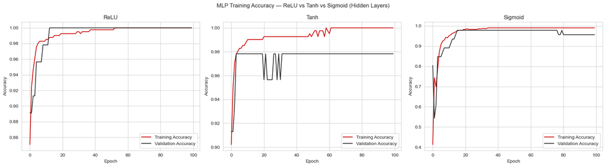

```python
fig, axes = plt.subplots(1, 3, figsize=(18, 5))
titles = {'relu': 'ReLU', 'tanh': 'Tanh', 'sigmoid': 'Sigmoid'}
for ax, act in zip(axes, activations):
    h = activation_histories[act]
    ax.plot(h.history['accuracy'], label='Training Accuracy', color='#CC0000')
    ax.plot(h.history['val_accuracy'], label='Validation Accuracy', color='#2C2C2C')
    ax.set_title(titles[act])
    ax.set_xlabel('Epoch')
    ax.set_ylabel('Accuracy')
    ax.legend()
fig.suptitle('MLP Training Accuracy — ReLU vs Tanh vs Sigmoid (Hidden Layers)')
plt.tight_layout()
plt.savefig('plots/activation_comparison.png')
plt.show()
```

```python
activation_val_acc = {act: activation_histories[act].history['val_accuracy'][-1] for act in activations}
print("Final validation accuracy per activation:")
for act, acc in activation_val_acc.items():
    print(f"{act}: {acc:.4f}")
best_activation = max(activation_val_acc, key=activation_val_acc.get)
best_activation
```

```
Final validation accuracy per activation:
relu: 1.0000
tanh: 0.9783
sigmoid: 0.9565
```

```
'relu'
```

```python
best_mlp_model = activation_models[best_activation]
mlp_loss, mlp_acc = best_mlp_model.evaluate(x_test_sc, y_test, verbose=0)
y_pred_mlp = (best_mlp_model.predict(x_test_sc) > 0.5).astype(int)
print("Best activation:", best_activation)
print("Test Accuracy:", mlp_acc)
```

```
4/4 ━━━━━━━━━━━━━━━━━━━━ 0s 28ms/step
Best activation: relu
Test Accuracy: 0.9561403393745422
```

```python
mlp_precision = precision_score(y_test, y_pred_mlp)
mlp_recall = recall_score(y_test, y_pred_mlp)
mlp_f1 = f1_score(y_test, y_pred_mlp)
results[f'MLP-{best_activation}'] = {
    'Architecture': f'Dense(64,{best_activation})-Dense(32,{best_activation})-Dense(1,sigmoid)',
    'Regularization': 'None',
    'Dropout Rate': 'None',
    'Early Stopping': 'No',
    'Test Accuracy': mlp_acc,
    'Test Precision': mlp_precision,
    'Test Recall': mlp_recall,
    'Test F1-Score': mlp_f1
}
print("SLP test accuracy:", slp_acc)
print(f"Best MLP ({best_activation}) test accuracy:", mlp_acc)
```

```
SLP test accuracy: 0.9298245906829834
Best MLP (relu) test accuracy: 0.9561403393745422
```

## Task 4 - Early Stopping

```python
model_es = Sequential()
model_es.add(Dense(128, activation='relu',input_dim = 30))
model_es.add(Dense(64, activation='relu'))
model_es.add(Dense(1, activation='sigmoid'))
model_es.summary()
```

```
Model: "sequential_5"
```

```
┏━━━━━━━━━━━━━━━━━━━━━━━━━━━━━━━━━━━━━━┳━━━━━━━━━━━━━━━━━━━━━━━━━━━━━┳━━━━━━━━━━━━━━━━━┓
┃ Layer (type)                         ┃ Output Shape                ┃         Param # ┃
┡━━━━━━━━━━━━━━━━━━━━━━━━━━━━━━━━━━━━━━╇━━━━━━━━━━━━━━━━━━━━━━━━━━━━━╇━━━━━━━━━━━━━━━━━┩
│ dense_13 (Dense)                     │ (None, 128)                 │           3,968 │
├──────────────────────────────────────┼─────────────────────────────┼─────────────────┤
│ dense_14 (Dense)                     │ (None, 64)                  │           8,256 │
├──────────────────────────────────────┼─────────────────────────────┼─────────────────┤
│ dense_15 (Dense)                     │ (None, 1)                   │              65 │
└──────────────────────────────────────┴─────────────────────────────┴─────────────────┘
```

```
 Total params: 12,289 (48.00 KB)
```

```
 Trainable params: 12,289 (48.00 KB)
```

```
 Non-trainable params: 0 (0.00 B)
```

```python
from tensorflow.keras.callbacks import EarlyStopping
```

```python
model_es.compile(optimizer = 'adam', loss = 'binary_crossentropy', metrics = ['accuracy'])
es = EarlyStopping(monitor='val_loss',patience=15,restore_best_weights=True,verbose=1)
history_es = model_es.fit(x_train_sc,y_train,epochs = 300, batch_size = 32, validation_split = 0.1, callbacks = [es],verbose=1)
```

```
13/13 ━━━━━━━━━━━━━━━━━━━━ 2s 41ms/step - accuracy: 0.8191 - loss: 0.4255 - val_accuracy: 0.9565 - val_loss: 0.2649
13/13 ━━━━━━━━━━━━━━━━━━━━ 0s 16ms/step - accuracy: 0.9584 - loss: 0.1575 - val_accuracy: 0.9565 - val_loss: 0.1614
13/13 ━━━━━━━━━━━━━━━━━━━━ 0s 13ms/step - accuracy: 0.9731 - loss: 0.0998 - val_accuracy: 0.9565 - val_loss: 0.1106
13/13 ━━━━━━━━━━━━━━━━━━━━ 0s 11ms/step - accuracy: 0.9780 - loss: 0.0752 - val_accuracy: 0.9565 - val_loss: 0.0824
13/13 ━━━━━━━━━━━━━━━━━━━━ 0s 13ms/step - accuracy: 0.9829 - loss: 0.0620 - val_accuracy: 0.9565 - val_loss: 0.0717
13/13 ━━━━━━━━━━━━━━━━━━━━ 0s 13ms/step - accuracy: 0.9902 - loss: 0.0538 - val_accuracy: 0.9565 - val_loss: 0.0620
13/13 ━━━━━━━━━━━━━━━━━━━━ 0s 13ms/step - accuracy: 0.9902 - loss: 0.0482 - val_accuracy: 0.9565 - val_loss: 0.0565
13/13 ━━━━━━━━━━━━━━━━━━━━ 0s 12ms/step - accuracy: 0.9902 - loss: 0.0429 - val_accuracy: 0.9783 - val_loss: 0.0532
13/13 ━━━━━━━━━━━━━━━━━━━━ 0s 11ms/step - accuracy: 0.9927 - loss: 0.0386 - val_accuracy: 0.9783 - val_loss: 0.0496
13/13 ━━━━━━━━━━━━━━━━━━━━ 0s 11ms/step - accuracy: 0.9927 - loss: 0.0345 - val_accuracy: 1.0000 - val_loss: 0.0459
13/13 ━━━━━━━━━━━━━━━━━━━━ 0s 17ms/step - accuracy: 0.9927 - loss: 0.0316 - val_accuracy: 1.0000 - val_loss: 0.0419
13/13 ━━━━━━━━━━━━━━━━━━━━ 0s 12ms/step - accuracy: 0.9927 - loss: 0.0277 - val_accuracy: 1.0000 - val_loss: 0.0404
13/13 ━━━━━━━━━━━━━━━━━━━━ 0s 11ms/step - accuracy: 0.9927 - loss: 0.0258 - val_accuracy: 1.0000 - val_loss: 0.0383
13/13 ━━━━━━━━━━━━━━━━━━━━ 0s 12ms/step - accuracy: 0.9927 - loss: 0.0227 - val_accuracy: 1.0000 - val_loss: 0.0377
13/13 ━━━━━━━━━━━━━━━━━━━━ 0s 13ms/step - accuracy: 0.9927 - loss: 0.0207 - val_accuracy: 1.0000 - val_loss: 0.0368
13/13 ━━━━━━━━━━━━━━━━━━━━ 0s 13ms/step - accuracy: 0.9927 - loss: 0.0188 - val_accuracy: 1.0000 - val_loss: 0.0340
13/13 ━━━━━━━━━━━━━━━━━━━━ 0s 11ms/step - accuracy: 0.9927 - loss: 0.0176 - val_accuracy: 1.0000 - val_loss: 0.0299
13/13 ━━━━━━━━━━━━━━━━━━━━ 0s 11ms/step - accuracy: 0.9976 - loss: 0.0156 - val_accuracy: 1.0000 - val_loss: 0.0304
13/13 ━━━━━━━━━━━━━━━━━━━━ 0s 11ms/step - accuracy: 0.9951 - loss: 0.0144 - val_accuracy: 1.0000 - val_loss: 0.0290
13/13 ━━━━━━━━━━━━━━━━━━━━ 0s 13ms/step - accuracy: 0.9951 - loss: 0.0133 - val_accuracy: 1.0000 - val_loss: 0.0300
13/13 ━━━━━━━━━━━━━━━━━━━━ 0s 12ms/step - accuracy: 0.9976 - loss: 0.0120 - val_accuracy: 1.0000 - val_loss: 0.0284
13/13 ━━━━━━━━━━━━━━━━━━━━ 0s 12ms/step - accuracy: 0.9976 - loss: 0.0110 - val_accuracy: 1.0000 - val_loss: 0.0248
13/13 ━━━━━━━━━━━━━━━━━━━━ 0s 11ms/step - accuracy: 0.9976 - loss: 0.0105 - val_accuracy: 1.0000 - val_loss: 0.0256
13/13 ━━━━━━━━━━━━━━━━━━━━ 0s 13ms/step - accuracy: 0.9976 - loss: 0.0090 - val_accuracy: 1.0000 - val_loss: 0.0249
13/13 ━━━━━━━━━━━━━━━━━━━━ 0s 14ms/step - accuracy: 0.9976 - loss: 0.0086 - val_accuracy: 1.0000 - val_loss: 0.0245
13/13 ━━━━━━━━━━━━━━━━━━━━ 0s 12ms/step - accuracy: 1.0000 - loss: 0.0079 - val_accuracy: 1.0000 - val_loss: 0.0229
13/13 ━━━━━━━━━━━━━━━━━━━━ 0s 12ms/step - accuracy: 1.0000 - loss: 0.0070 - val_accuracy: 1.0000 - val_loss: 0.0241
13/13 ━━━━━━━━━━━━━━━━━━━━ 0s 13ms/step - accuracy: 0.9976 - loss: 0.0072 - val_accuracy: 1.0000 - val_loss: 0.0232
13/13 ━━━━━━━━━━━━━━━━━━━━ 0s 15ms/step - accuracy: 1.0000 - loss: 0.0075 - val_accuracy: 1.0000 - val_loss: 0.0226
13/13 ━━━━━━━━━━━━━━━━━━━━ 0s 15ms/step - accuracy: 1.0000 - loss: 0.0053 - val_accuracy: 1.0000 - val_loss: 0.0246
13/13 ━━━━━━━━━━━━━━━━━━━━ 0s 15ms/step - accuracy: 0.9976 - loss: 0.0059 - val_accuracy: 1.0000 - val_loss: 0.0235
13/13 ━━━━━━━━━━━━━━━━━━━━ 0s 15ms/step - accuracy: 1.0000 - loss: 0.0050 - val_accuracy: 1.0000 - val_loss: 0.0205
13/13 ━━━━━━━━━━━━━━━━━━━━ 0s 15ms/step - accuracy: 1.0000 - loss: 0.0047 - val_accuracy: 1.0000 - val_loss: 0.0202
13/13 ━━━━━━━━━━━━━━━━━━━━ 0s 16ms/step - accuracy: 1.0000 - loss: 0.0043 - val_accuracy: 1.0000 - val_loss: 0.0214
13/13 ━━━━━━━━━━━━━━━━━━━━ 0s 16ms/step - accuracy: 1.0000 - loss: 0.0042 - val_accuracy: 1.0000 - val_loss: 0.0210
13/13 ━━━━━━━━━━━━━━━━━━━━ 0s 18ms/step - accuracy: 1.0000 - loss: 0.0035 - val_accuracy: 1.0000 - val_loss: 0.0229
13/13 ━━━━━━━━━━━━━━━━━━━━ 0s 12ms/step - accuracy: 1.0000 - loss: 0.0036 - val_accuracy: 1.0000 - val_loss: 0.0192
13/13 ━━━━━━━━━━━━━━━━━━━━ 0s 11ms/step - accuracy: 1.0000 - loss: 0.0031 - val_accuracy: 1.0000 - val_loss: 0.0198
13/13 ━━━━━━━━━━━━━━━━━━━━ 0s 11ms/step - accuracy: 1.0000 - loss: 0.0029 - val_accuracy: 1.0000 - val_loss: 0.0207
13/13 ━━━━━━━━━━━━━━━━━━━━ 0s 11ms/step - accuracy: 1.0000 - loss: 0.0027 - val_accuracy: 1.0000 - val_loss: 0.0211
```

[output cut: 246 more lines]

```
13/13 ━━━━━━━━━━━━━━━━━━━━ 0s 16ms/step - accuracy: 1.0000 - loss: 1.2734e-05 - val_accuracy: 1.0000 - val_loss: 0.0033
13/13 ━━━━━━━━━━━━━━━━━━━━ 0s 19ms/step - accuracy: 1.0000 - loss: 1.2691e-05 - val_accuracy: 1.0000 - val_loss: 0.0032
13/13 ━━━━━━━━━━━━━━━━━━━━ 0s 18ms/step - accuracy: 1.0000 - loss: 1.2348e-05 - val_accuracy: 1.0000 - val_loss: 0.0032
13/13 ━━━━━━━━━━━━━━━━━━━━ 0s 27ms/step - accuracy: 1.0000 - loss: 1.2298e-05 - val_accuracy: 1.0000 - val_loss: 0.0033
13/13 ━━━━━━━━━━━━━━━━━━━━ 1s 15ms/step - accuracy: 1.0000 - loss: 1.2117e-05 - val_accuracy: 1.0000 - val_loss: 0.0032
13/13 ━━━━━━━━━━━━━━━━━━━━ 0s 15ms/step - accuracy: 1.0000 - loss: 1.2062e-05 - val_accuracy: 1.0000 - val_loss: 0.0032
13/13 ━━━━━━━━━━━━━━━━━━━━ 0s 13ms/step - accuracy: 1.0000 - loss: 1.2233e-05 - val_accuracy: 1.0000 - val_loss: 0.0032
13/13 ━━━━━━━━━━━━━━━━━━━━ 0s 16ms/step - accuracy: 1.0000 - loss: 1.1883e-05 - val_accuracy: 1.0000 - val_loss: 0.0031
13/13 ━━━━━━━━━━━━━━━━━━━━ 0s 15ms/step - accuracy: 1.0000 - loss: 1.1721e-05 - val_accuracy: 1.0000 - val_loss: 0.0032
13/13 ━━━━━━━━━━━━━━━━━━━━ 0s 13ms/step - accuracy: 1.0000 - loss: 1.1534e-05 - val_accuracy: 1.0000 - val_loss: 0.0032
13/13 ━━━━━━━━━━━━━━━━━━━━ 0s 16ms/step - accuracy: 1.0000 - loss: 1.1389e-05 - val_accuracy: 1.0000 - val_loss: 0.0032
13/13 ━━━━━━━━━━━━━━━━━━━━ 0s 12ms/step - accuracy: 1.0000 - loss: 1.1279e-05 - val_accuracy: 1.0000 - val_loss: 0.0031
13/13 ━━━━━━━━━━━━━━━━━━━━ 0s 23ms/step - accuracy: 1.0000 - loss: 1.1160e-05 - val_accuracy: 1.0000 - val_loss: 0.0031
13/13 ━━━━━━━━━━━━━━━━━━━━ 0s 17ms/step - accuracy: 1.0000 - loss: 1.1039e-05 - val_accuracy: 1.0000 - val_loss: 0.0031
Restoring model weights from the end of the best epoch: 300.
```

```
Training stopped at epoch: 300
```

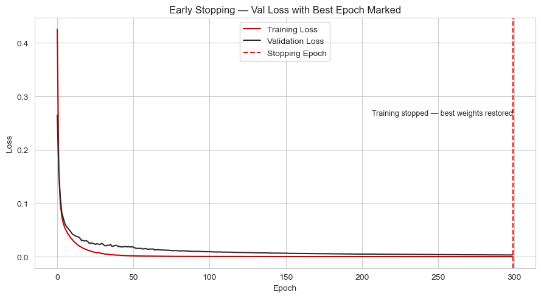

```python
stopping_epoch = len(history_es.history['loss'])
print("Training stopped at epoch:", stopping_epoch)
plt.figure(figsize=(9, 5))
plt.plot(history_es.history['loss'], label='Training Loss', color='#CC0000')
plt.plot(history_es.history['val_loss'], label='Validation Loss', color='#2C2C2C')
plt.axvline(x=stopping_epoch - 1, color='red', linestyle='--', label='Stopping Epoch')
plt.annotate('Training stopped — best weights restored',
             xy=(stopping_epoch - 1, max(history_es.history['val_loss'])),
             xytext=(stopping_epoch - 1, max(history_es.history['val_loss'])),
             ha='right', fontsize=9)
plt.title('Early Stopping — Val Loss with Best Epoch Marked')
plt.xlabel('Epoch')
plt.ylabel('Loss')
plt.legend()
plt.tight_layout()
plt.savefig('plots/early_stopping_curve.png')
plt.show()
```

```python
model_no_es = keras.Sequential([
    keras.Input(shape=(30,)),
    keras.layers.Dense(128, activation='relu'),
    keras.layers.Dense(64, activation='relu'),
    keras.layers.Dense(1, activation='sigmoid')
])
model_no_es.compile(
    optimizer='adam',
    loss='binary_crossentropy',
    metrics=['accuracy']
)
history_no_es = model_no_es.fit(
    x_train_sc,
    y_train,
    epochs=300,
    batch_size=32,
    validation_split=0.1,
    verbose=0
)
print("Training without Early Stopping finished.")
```

```
Training without Early Stopping finished.
```

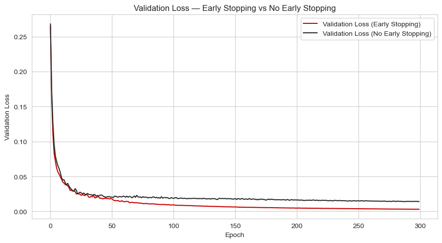

```python
plt.figure(figsize=(9, 5))
plt.plot(history_es.history['val_loss'], label='Validation Loss (Early Stopping)', color='#CC0000')
plt.plot(history_no_es.history['val_loss'], label='Validation Loss (No Early Stopping)', color='#2C2C2C')
plt.title('Validation Loss — Early Stopping vs No Early Stopping')
plt.xlabel('Epoch')
plt.ylabel('Validation Loss')
plt.legend()
plt.tight_layout()
plt.savefig('plots/es_comparison.png')
plt.show()
```

```python
es_loss, es_acc = model_es.evaluate(x_test_sc, y_test, verbose=0)
no_es_loss, no_es_acc = model_no_es.evaluate(x_test_sc, y_test, verbose=0)

min_val_loss_no_es = min(history_no_es.history['val_loss'])
min_val_loss_epoch_no_es = int(np.argmin(history_no_es.history['val_loss'])) + 1

print("Early Stopping model — Test Accuracy:", es_acc, "| Test Loss:", es_loss)
print("No Early Stopping model — Test Accuracy:", no_es_acc, "| Test Loss:", no_es_loss)
```

```
Early Stopping model — Test Accuracy: 0.9561403393745422 | Test Loss: 0.2217959314584732
No Early Stopping model — Test Accuracy: 0.9473684430122375 | Test Loss: 0.3490830063819885
```

```python
y_pred_es = (model_es.predict(x_test_sc) > 0.5).astype(int)
es_precision = precision_score(y_test, y_pred_es)
es_recall = recall_score(y_test, y_pred_es)
es_f1 = f1_score(y_test, y_pred_es)

results['MLP + Early Stopping'] = {
    'Architecture': 'Dense(128,relu)-Dense(64,relu)-Dense(1,sigmoid)',
    'Regularization': 'None',
    'Dropout Rate': 'None',
    'Early Stopping': 'Yes (patience=15)',
    'Test Accuracy': es_acc,
    'Test Precision': es_precision,
    'Test Recall': es_recall,
    'Test F1-Score': es_f1
}
results['MLP + Early Stopping']
```

```
WARNING:tensorflow:5 out of the last 9 calls to <function TensorFlowTrainer.make_predict_function.<locals>.one_step_on_data_distributed at 0x00000196AAF39DA0> triggered tf.function retracing. Tracing is expensive and the excessive number of tracings could be due to (1) creating @tf.function repeated…
WARNING:tensorflow:6 out of the last 12 calls to <function TensorFlowTrainer.make_predict_function.<locals>.one_step_on_data_distributed at 0x00000196AAF39DA0> triggered tf.function retracing. Tracing is expensive and the excessive number of tracings could be due to (1) creating @tf.function repeate…
4/4 ━━━━━━━━━━━━━━━━━━━━ 0s 32ms/step
```

```
{'Architecture': 'Dense(128,relu)-Dense(64,relu)-Dense(1,sigmoid)',
 'Regularization': 'None',
 'Dropout Rate': 'None',
 'Early Stopping': 'Yes (patience=15)',
 'Test Accuracy': 0.9561403393745422,
 'Test Precision': 0.9855072463768116,
 'Test Recall': 0.9444444444444444,
 'Test F1-Score': 0.9645390070921985}
```

## Task 5: Dropout Layers

```python
model_drop = Sequential()
model_drop.add(Dense(128,activation='relu',input_dim = 30))
model_drop.add(Dropout(0.3))
model_drop.add(Dense(64,activation='relu'))
model_drop.add(Dropout(0.3))
model_drop.add(Dense(1,activation='sigmoid'))
model_drop.summary()
```

```
Model: "sequential_7"
```

```
┏━━━━━━━━━━━━━━━━━━━━━━━━━━━━━━━━━━━━━━┳━━━━━━━━━━━━━━━━━━━━━━━━━━━━━┳━━━━━━━━━━━━━━━━━┓
┃ Layer (type)                         ┃ Output Shape                ┃         Param # ┃
┡━━━━━━━━━━━━━━━━━━━━━━━━━━━━━━━━━━━━━━╇━━━━━━━━━━━━━━━━━━━━━━━━━━━━━╇━━━━━━━━━━━━━━━━━┩
│ dense_19 (Dense)                     │ (None, 128)                 │           3,968 │
├──────────────────────────────────────┼─────────────────────────────┼─────────────────┤
│ dropout (Dropout)                    │ (None, 128)                 │               0 │
├──────────────────────────────────────┼─────────────────────────────┼─────────────────┤
│ dense_20 (Dense)                     │ (None, 64)                  │           8,256 │
├──────────────────────────────────────┼─────────────────────────────┼─────────────────┤
│ dropout_1 (Dropout)                  │ (None, 64)                  │               0 │
├──────────────────────────────────────┼─────────────────────────────┼─────────────────┤
│ dense_21 (Dense)                     │ (None, 1)                   │              65 │
└──────────────────────────────────────┴─────────────────────────────┴─────────────────┘
```

```
 Total params: 12,289 (48.00 KB)
```

```
 Trainable params: 12,289 (48.00 KB)
```

```
 Non-trainable params: 0 (0.00 B)
```

### - Why Dropout

- Dropout randomly turns off some neuron activations during training.
- `Dropout(0.3)` means approximately 30 percent of activations from the previous layer are dropped (set to zero) during each training step.
- This prevents the network from depending too much on any particular neuron, because that neuron might not be available in the next step.
- This can reduce overfitting because the network is forced to learn more general, redundant patterns instead of memorizing exact training examples.
- During prediction (inference), Dropout is automatically disabled and all neurons are used.

```python
model_drop.compile(optimizer = 'adam', loss = 'binary_crossentropy', metrics = ['accuracy'])
es_drop = EarlyStopping(monitor='val_loss',patience=20,restore_best_weights=True,verbose=1)
history_drop = model_drop.fit(x_train_sc,y_train,epochs = 300, batch_size = 32, validation_split = 0.1, callbacks = [es_drop],verbose=1)
```

```
13/13 ━━━━━━━━━━━━━━━━━━━━ 3s 35ms/step - accuracy: 0.7531 - loss: 0.5512 - val_accuracy: 0.9348 - val_loss: 0.3420
13/13 ━━━━━━━━━━━━━━━━━━━━ 0s 14ms/step - accuracy: 0.9487 - loss: 0.2590 - val_accuracy: 0.9348 - val_loss: 0.2149
13/13 ━━━━━━━━━━━━━━━━━━━━ 0s 11ms/step - accuracy: 0.9560 - loss: 0.1581 - val_accuracy: 0.9565 - val_loss: 0.1596
13/13 ━━━━━━━━━━━━━━━━━━━━ 0s 11ms/step - accuracy: 0.9609 - loss: 0.1247 - val_accuracy: 0.9565 - val_loss: 0.1260
13/13 ━━━━━━━━━━━━━━━━━━━━ 0s 14ms/step - accuracy: 0.9682 - loss: 0.1029 - val_accuracy: 0.9565 - val_loss: 0.1052
13/13 ━━━━━━━━━━━━━━━━━━━━ 0s 12ms/step - accuracy: 0.9682 - loss: 0.0888 - val_accuracy: 0.9783 - val_loss: 0.0859
13/13 ━━━━━━━━━━━━━━━━━━━━ 0s 13ms/step - accuracy: 0.9829 - loss: 0.0760 - val_accuracy: 0.9783 - val_loss: 0.0773
13/13 ━━━━━━━━━━━━━━━━━━━━ 0s 22ms/step - accuracy: 0.9829 - loss: 0.0661 - val_accuracy: 0.9783 - val_loss: 0.0693
13/13 ━━━━━━━━━━━━━━━━━━━━ 0s 14ms/step - accuracy: 0.9853 - loss: 0.0619 - val_accuracy: 0.9783 - val_loss: 0.0636
13/13 ━━━━━━━━━━━━━━━━━━━━ 0s 13ms/step - accuracy: 0.9804 - loss: 0.0622 - val_accuracy: 0.9783 - val_loss: 0.0577
13/13 ━━━━━━━━━━━━━━━━━━━━ 0s 14ms/step - accuracy: 0.9853 - loss: 0.0601 - val_accuracy: 0.9783 - val_loss: 0.0557
13/13 ━━━━━━━━━━━━━━━━━━━━ 0s 14ms/step - accuracy: 0.9853 - loss: 0.0567 - val_accuracy: 0.9783 - val_loss: 0.0496
13/13 ━━━━━━━━━━━━━━━━━━━━ 0s 13ms/step - accuracy: 0.9853 - loss: 0.0569 - val_accuracy: 0.9783 - val_loss: 0.0472
13/13 ━━━━━━━━━━━━━━━━━━━━ 0s 12ms/step - accuracy: 0.9829 - loss: 0.0543 - val_accuracy: 0.9783 - val_loss: 0.0488
13/13 ━━━━━━━━━━━━━━━━━━━━ 0s 13ms/step - accuracy: 0.9902 - loss: 0.0425 - val_accuracy: 0.9783 - val_loss: 0.0452
13/13 ━━━━━━━━━━━━━━━━━━━━ 0s 11ms/step - accuracy: 0.9878 - loss: 0.0433 - val_accuracy: 0.9783 - val_loss: 0.0421
13/13 ━━━━━━━━━━━━━━━━━━━━ 0s 11ms/step - accuracy: 0.9902 - loss: 0.0368 - val_accuracy: 0.9783 - val_loss: 0.0415
13/13 ━━━━━━━━━━━━━━━━━━━━ 0s 13ms/step - accuracy: 0.9878 - loss: 0.0402 - val_accuracy: 0.9783 - val_loss: 0.0443
13/13 ━━━━━━━━━━━━━━━━━━━━ 0s 13ms/step - accuracy: 0.9927 - loss: 0.0318 - val_accuracy: 0.9783 - val_loss: 0.0388
13/13 ━━━━━━━━━━━━━━━━━━━━ 0s 12ms/step - accuracy: 0.9902 - loss: 0.0457 - val_accuracy: 0.9783 - val_loss: 0.0329
13/13 ━━━━━━━━━━━━━━━━━━━━ 0s 13ms/step - accuracy: 0.9902 - loss: 0.0359 - val_accuracy: 1.0000 - val_loss: 0.0312
13/13 ━━━━━━━━━━━━━━━━━━━━ 0s 12ms/step - accuracy: 0.9927 - loss: 0.0296 - val_accuracy: 0.9783 - val_loss: 0.0316
13/13 ━━━━━━━━━━━━━━━━━━━━ 0s 11ms/step - accuracy: 0.9878 - loss: 0.0331 - val_accuracy: 1.0000 - val_loss: 0.0299
13/13 ━━━━━━━━━━━━━━━━━━━━ 0s 11ms/step - accuracy: 0.9927 - loss: 0.0301 - val_accuracy: 1.0000 - val_loss: 0.0279
13/13 ━━━━━━━━━━━━━━━━━━━━ 0s 11ms/step - accuracy: 0.9927 - loss: 0.0253 - val_accuracy: 1.0000 - val_loss: 0.0256
13/13 ━━━━━━━━━━━━━━━━━━━━ 0s 12ms/step - accuracy: 0.9878 - loss: 0.0323 - val_accuracy: 1.0000 - val_loss: 0.0334
13/13 ━━━━━━━━━━━━━━━━━━━━ 0s 13ms/step - accuracy: 0.9927 - loss: 0.0223 - val_accuracy: 0.9783 - val_loss: 0.0372
13/13 ━━━━━━━━━━━━━━━━━━━━ 0s 13ms/step - accuracy: 0.9902 - loss: 0.0211 - val_accuracy: 1.0000 - val_loss: 0.0293
13/13 ━━━━━━━━━━━━━━━━━━━━ 0s 13ms/step - accuracy: 0.9902 - loss: 0.0278 - val_accuracy: 1.0000 - val_loss: 0.0237
13/13 ━━━━━━━━━━━━━━━━━━━━ 0s 12ms/step - accuracy: 0.9951 - loss: 0.0220 - val_accuracy: 1.0000 - val_loss: 0.0206
13/13 ━━━━━━━━━━━━━━━━━━━━ 0s 13ms/step - accuracy: 0.9902 - loss: 0.0267 - val_accuracy: 1.0000 - val_loss: 0.0215
13/13 ━━━━━━━━━━━━━━━━━━━━ 0s 13ms/step - accuracy: 0.9902 - loss: 0.0253 - val_accuracy: 1.0000 - val_loss: 0.0202
13/13 ━━━━━━━━━━━━━━━━━━━━ 0s 13ms/step - accuracy: 0.9927 - loss: 0.0212 - val_accuracy: 1.0000 - val_loss: 0.0194
13/13 ━━━━━━━━━━━━━━━━━━━━ 0s 11ms/step - accuracy: 0.9902 - loss: 0.0215 - val_accuracy: 1.0000 - val_loss: 0.0183
13/13 ━━━━━━━━━━━━━━━━━━━━ 0s 12ms/step - accuracy: 0.9927 - loss: 0.0215 - val_accuracy: 1.0000 - val_loss: 0.0161
13/13 ━━━━━━━━━━━━━━━━━━━━ 0s 11ms/step - accuracy: 0.9951 - loss: 0.0150 - val_accuracy: 1.0000 - val_loss: 0.0155
13/13 ━━━━━━━━━━━━━━━━━━━━ 0s 13ms/step - accuracy: 0.9902 - loss: 0.0226 - val_accuracy: 1.0000 - val_loss: 0.0164
13/13 ━━━━━━━━━━━━━━━━━━━━ 0s 13ms/step - accuracy: 0.9951 - loss: 0.0155 - val_accuracy: 1.0000 - val_loss: 0.0162
13/13 ━━━━━━━━━━━━━━━━━━━━ 0s 17ms/step - accuracy: 0.9951 - loss: 0.0157 - val_accuracy: 1.0000 - val_loss: 0.0194
13/13 ━━━━━━━━━━━━━━━━━━━━ 0s 14ms/step - accuracy: 0.9951 - loss: 0.0140 - val_accuracy: 1.0000 - val_loss: 0.0243
```

[output cut: 37 more lines]

```
13/13 ━━━━━━━━━━━━━━━━━━━━ 0s 13ms/step - accuracy: 0.9976 - loss: 0.0088 - val_accuracy: 1.0000 - val_loss: 0.0084
13/13 ━━━━━━━━━━━━━━━━━━━━ 0s 13ms/step - accuracy: 1.0000 - loss: 0.0033 - val_accuracy: 1.0000 - val_loss: 0.0117
13/13 ━━━━━━━━━━━━━━━━━━━━ 0s 13ms/step - accuracy: 1.0000 - loss: 0.0040 - val_accuracy: 1.0000 - val_loss: 0.0111
13/13 ━━━━━━━━━━━━━━━━━━━━ 0s 15ms/step - accuracy: 1.0000 - loss: 0.0038 - val_accuracy: 1.0000 - val_loss: 0.0116
13/13 ━━━━━━━━━━━━━━━━━━━━ 0s 18ms/step - accuracy: 1.0000 - loss: 0.0023 - val_accuracy: 1.0000 - val_loss: 0.0123
13/13 ━━━━━━━━━━━━━━━━━━━━ 0s 18ms/step - accuracy: 1.0000 - loss: 0.0028 - val_accuracy: 1.0000 - val_loss: 0.0119
13/13 ━━━━━━━━━━━━━━━━━━━━ 0s 18ms/step - accuracy: 1.0000 - loss: 0.0020 - val_accuracy: 1.0000 - val_loss: 0.0113
13/13 ━━━━━━━━━━━━━━━━━━━━ 0s 18ms/step - accuracy: 0.9976 - loss: 0.0036 - val_accuracy: 1.0000 - val_loss: 0.0090
13/13 ━━━━━━━━━━━━━━━━━━━━ 0s 15ms/step - accuracy: 1.0000 - loss: 0.0025 - val_accuracy: 1.0000 - val_loss: 0.0083
13/13 ━━━━━━━━━━━━━━━━━━━━ 0s 12ms/step - accuracy: 1.0000 - loss: 0.0020 - val_accuracy: 1.0000 - val_loss: 0.0078
13/13 ━━━━━━━━━━━━━━━━━━━━ 0s 12ms/step - accuracy: 0.9976 - loss: 0.0054 - val_accuracy: 1.0000 - val_loss: 0.0112
13/13 ━━━━━━━━━━━━━━━━━━━━ 0s 15ms/step - accuracy: 1.0000 - loss: 0.0038 - val_accuracy: 1.0000 - val_loss: 0.0144
13/13 ━━━━━━━━━━━━━━━━━━━━ 0s 16ms/step - accuracy: 1.0000 - loss: 0.0049 - val_accuracy: 1.0000 - val_loss: 0.0100
Epoch 90: early stopping
Restoring model weights from the end of the best epoch: 70.
```

```python
def build_dropout_model(rate):
    model = keras.Sequential([
        keras.Input(shape=(30,)),
        keras.layers.Dense(128, activation='relu'),
        keras.layers.Dropout(rate),
        keras.layers.Dense(64, activation='relu'),
        keras.layers.Dropout(rate),
        keras.layers.Dense(1, activation='sigmoid')
    ])
    model.compile(optimizer='adam', loss='binary_crossentropy', metrics=['accuracy'])
    return model
dropout_rates = [0.1, 0.3, 0.5]
dropout_models = {}
dropout_histories = {}
```

```python
for rate in dropout_rates:
    model = build_dropout_model(rate)
    es_rate = EarlyStopping(monitor='val_loss', patience=20, restore_best_weights=True, verbose=0)
    history = model.fit(
        x_train_sc,
        y_train,
        epochs=200,
        batch_size=32,
        validation_split=0.1,
        callbacks=[es_rate],
        verbose=0
    )
    dropout_models[rate] = model
    dropout_histories[rate] = history
    print(f"Dropout {rate} training done, stopped at epoch {len(history.history['loss'])}")
```

```
Dropout 0.1 training done, stopped at epoch 88
Dropout 0.3 training done, stopped at epoch 103
Dropout 0.5 training done, stopped at epoch 141
```

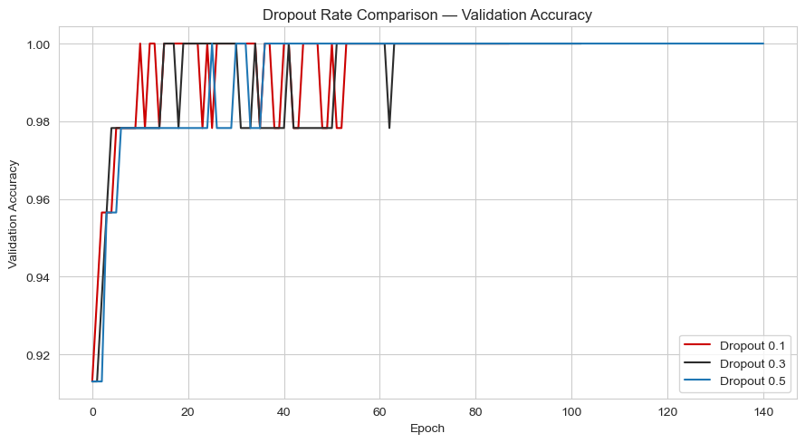

```python
plt.figure(figsize=(9, 5))
colors = {0.1: '#CC0000', 0.3: '#2C2C2C', 0.5: '#1f77b4'}
for rate in dropout_rates:
    plt.plot(dropout_histories[rate].history['val_accuracy'], label=f'Dropout {rate}', color=colors[rate])
plt.title('Dropout Rate Comparison — Validation Accuracy')
plt.xlabel('Epoch')
plt.ylabel('Validation Accuracy')
plt.legend()
plt.tight_layout()
plt.savefig('plots/dropout_comparison.png')
plt.show()
```

```python
dropout_val_acc = {rate: max(dropout_histories[rate].history['val_accuracy']) for rate in dropout_rates}
print("Best validation accuracy per dropout rate:")
for rate, acc in dropout_val_acc.items():
    print(f"Dropout {rate}: {acc:.4f}")
best_dropout_rate = max(dropout_val_acc, key=dropout_val_acc.get)
print("Best dropout rate based on validation accuracy:", best_dropout_rate)
```

```
Best validation accuracy per dropout rate:
Dropout 0.1: 1.0000
Dropout 0.3: 1.0000
Dropout 0.5: 1.0000
Best dropout rate based on validation accuracy: 0.1
```

```python
best_dropout_model = dropout_models[best_dropout_rate]
drop_loss, drop_acc = best_dropout_model.evaluate(x_test_sc, y_test, verbose=0)
y_pred_drop = (best_dropout_model.predict(x_test_sc) > 0.5).astype(int)
drop_precision = precision_score(y_test, y_pred_drop)
drop_recall = recall_score(y_test, y_pred_drop)
drop_f1 = f1_score(y_test, y_pred_drop)
print("Best Dropout rate:", best_dropout_rate)
print("Test Accuracy:", drop_acc)
print("Test Precision:", drop_precision)
print("Test Recall:", drop_recall)
print("Test F1-Score:", drop_f1)
results[f'MLP + Dropout-best ({best_dropout_rate})'] = {
    'Architecture':f'Dense(128,relu)-Dropout({best_dropout_rate})-Dense(64,relu)-Dropout({best_dropout_rate})-Dense(1,sigmoid)',
    'Regularization': 'None',
    'Dropout Rate': best_dropout_rate,
    'Early Stopping': 'Yes (patience=20)',
    'Test Accuracy': drop_acc,
    'Test Precision': drop_precision,
    'Test Recall': drop_recall,
    'Test F1-Score': drop_f1
}
```

```
4/4 ━━━━━━━━━━━━━━━━━━━━ 0s 60ms/step
Best Dropout rate: 0.1
Test Accuracy: 0.9561403393745422
Test Precision: 0.9855072463768116
Test Recall: 0.9444444444444444
Test F1-Score: 0.9645390070921985
```

```python
final_train_acc_drop = dropout_histories[best_dropout_rate].history['accuracy'][-1]
final_val_acc_drop = dropout_histories[best_dropout_rate].history['val_accuracy'][-1]
final_train_acc_mlp = activation_histories[best_activation].history['accuracy'][-1]
final_val_acc_mlp = activation_histories[best_activation].history['val_accuracy'][-1]
print("MLP without Dropout — Train Accuracy:", final_train_acc_mlp, "| Val Accuracy:", final_val_acc_mlp)
print()
print(f"MLP with Dropout ({best_dropout_rate}) — Train Accuracy:", final_train_acc_drop, "| Val Accuracy:", final_val_acc_drop)
```

```
MLP without Dropout — Train Accuracy: 1.0 | Val Accuracy: 1.0

MLP with Dropout (0.1) — Train Accuracy: 1.0 | Val Accuracy: 1.0
```

## Task 6: Regularization — L1, L2, L1-L2

```python
model_l2 = Sequential()
model_l2.add(Dense(128,activation='relu',input_dim = 30,kernel_regularizer=regularizers.l2(0.001)))
model_l2.add(Dense(64,activation='relu',kernel_regularizer=regularizers.l2(0.001)))
model_l2.add(Dense(1,activation='sigmoid'))
```

### - Why L2 Regularization

- L2 regularization adds a penalty to the loss based on the sum of squared weights.
- It encourages the weights to stay small, instead of growing very large.
- Small weights usually create a smoother, simpler decision boundary, which can reduce overfitting.
- If the regularization strength is very large, it can force the weights to be too small, which can cause underfitting.
- We used `0.001` as the L2 value, which is the value specified in the assignment.

```python
model_l2.compile(optimizer = "adam", loss = 'binary_crossentropy',metrics = ['accuracy'])
es_l2 = EarlyStopping(monitor='val_loss', patience=20, restore_best_weights=True, verbose=0)
history_l2 = model_l2.fit(x_train_sc,y_train,epochs = 300,batch_size=32,validation_split=0.1,callbacks=[es_l2],verbose=0)
```

```python
model_l1 = Sequential()
model_l1.add(Dense(128,activation='relu',input_dim = 30,kernel_regularizer=regularizers.l1(0.001)))
model_l1.add(Dense(64,activation='relu',kernel_regularizer=regularizers.l1(0.001)))
model_l1.add(Dense(1,activation='sigmoid'))
model_l1.compile(optimizer = "adam", loss = 'binary_crossentropy',metrics = ['accuracy'])
es_l1 = EarlyStopping(monitor='val_loss', patience=20, restore_best_weights=True, verbose=0)
history_l1 = model_l1.fit(x_train_sc,y_train,epochs = 300,batch_size=32,validation_split=0.1,callbacks=[es_l1],verbose=0)
```

```python
model_l1l2 = Sequential()
model_l1l2.add(Dense(128,activation='relu',input_dim = 30,kernel_regularizer=regularizers.l1_l2(l1=0.0001, l2=0.001)))
model_l1l2.add(Dense(64,activation='relu',kernel_regularizer=regularizers.l1_l2(l1=0.0001, l2=0.001)))
model_l1l2.add(Dense(1,activation='sigmoid'))
model_l1l2.compile(optimizer = "adam", loss = 'binary_crossentropy',metrics = ['accuracy'])
es_l1l2 = EarlyStopping(monitor='val_loss', patience=20, restore_best_weights=True, verbose=0)
history_l1l2 = model_l1l2.fit(x_train_sc,y_train,epochs = 300,batch_size=32,validation_split=0.1,callbacks=[es_l1l2],verbose=0)
```

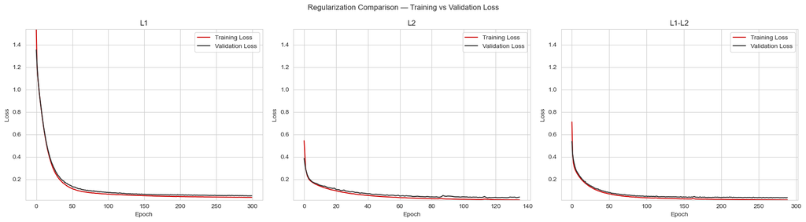

```python
fig, axes = plt.subplots(1, 3, figsize=(18, 5))
reg_histories = {'L1': history_l1, 'L2': history_l2, 'L1-L2': history_l1l2}
all_losses = []
for h in reg_histories.values():
    all_losses.extend(h.history['loss'])
    all_losses.extend(h.history['val_loss'])
y_min, y_max = min(all_losses), max(all_losses)
for ax, (name, h) in zip(axes, reg_histories.items()):
    ax.plot(h.history['loss'], label='Training Loss', color='#CC0000')
    ax.plot(h.history['val_loss'], label='Validation Loss', color='#2C2C2C')
    ax.set_title(name)
    ax.set_xlabel('Epoch')
    ax.set_ylabel('Loss')
    ax.set_ylim(y_min, y_max)
    ax.legend()
fig.suptitle('Regularization Comparison — Training vs Validation Loss')
plt.tight_layout()
plt.savefig('plots/regularization_comparison.png')
plt.show()
```

```python
for name, h in reg_histories.items():
    gap = h.history['loss'][-1] - h.history['val_loss'][-1]
    final_val_acc = h.history['val_accuracy'][-1]
    print(f"{name}: final train-val loss gap = {gap:.4f}, final val accuracy = {final_val_acc:.4f}")
```

```
L1: final train-val loss gap = -0.0142, final val accuracy = 1.0000
L2: final train-val loss gap = -0.0250, final val accuracy = 0.9783
L1-L2: final train-val loss gap = -0.0203, final val accuracy = 0.9783
```

```python
def evaluate_model(model, name):
    loss, acc = model.evaluate(x_test_sc, y_test, verbose=0)
    y_pred = (model.predict(x_test_sc, verbose=0) > 0.5).astype(int)
    precision = precision_score(y_test, y_pred)
    recall = recall_score(y_test, y_pred)
    f1 = f1_score(y_test, y_pred)
    print(f"{name}: acc={acc:.4f} precision={precision:.4f} recall={recall:.4f} f1={f1:.4f}")
    return acc, precision, recall, f1
l1_acc, l1_precision, l1_recall, l1_f1 = evaluate_model(model_l1, 'L1')
l2_acc, l2_precision, l2_recall, l2_f1 = evaluate_model(model_l2, 'L2')
l1l2_acc, l1l2_precision, l1l2_recall, l1l2_f1 = evaluate_model(model_l1l2, 'L1-L2')
```

```
L1: acc=0.9561 precision=0.9855 recall=0.9444 f1=0.9645
L2: acc=0.9561 precision=0.9855 recall=0.9444 f1=0.9645
L1-L2: acc=0.9561 precision=0.9855 recall=0.9444 f1=0.9645
```

```python
results['MLP + L1'] = {
    'Architecture': 'Dense(128,relu,L1)-Dense(64,relu,L1)-Dense(1,sigmoid)',
    'Regularization': 'L1 (0.001)',
    'Dropout Rate': 'None',
    'Early Stopping': 'Yes (patience=20)',
    'Test Accuracy': l1_acc, 'Test Precision': l1_precision, 'Test Recall': l1_recall, 'Test F1-Score': l1_f1
}
results['MLP + L2'] = {
    'Architecture': 'Dense(128,relu,L2)-Dense(64,relu,L2)-Dense(1,sigmoid)',
    'Regularization': 'L2 (0.001)',
    'Dropout Rate': 'None',
    'Early Stopping': 'Yes (patience=20)',
    'Test Accuracy': l2_acc, 'Test Precision': l2_precision, 'Test Recall': l2_recall, 'Test F1-Score': l2_f1
}
results['MLP + L1-L2'] = {
    'Architecture': 'Dense(128,relu,L1L2)-Dense(64,relu,L1L2)-Dense(1,sigmoid)',
    'Regularization': 'L1 (0.0001) + L2 (0.001)',
    'Dropout Rate': 'None',
    'Early Stopping': 'Yes (patience=20)',
    'Test Accuracy': l1l2_acc, 'Test Precision': l1l2_precision, 'Test Recall': l1l2_recall, 'Test F1-Score': l1l2_f1
}
bar_data = pd.DataFrame({
    'Model': ['No Regularization', 'L1', 'L2', 'L1-L2'],
    'Test Accuracy': [mlp_acc, l1_acc, l2_acc, l1l2_acc]
})
bar_data
```

|  | Model | Test Accuracy |
| --- | --- | --- |
| 0 | No Regularization | 0.95614 |
| 1 | L1 | 0.95614 |
| 2 | L2 | 0.95614 |
| 3 | L1-L2 | 0.95614 |

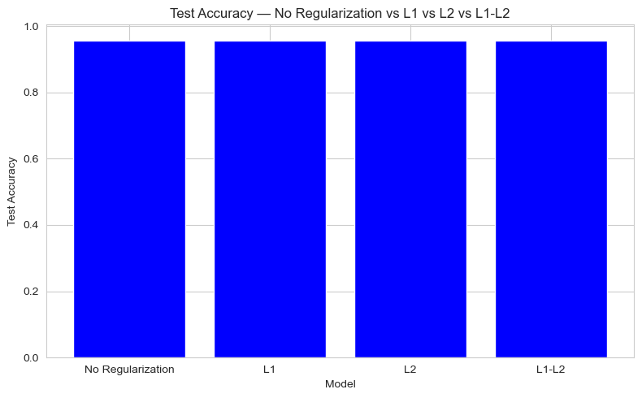

```python
plt.figure(figsize=(8, 5))
plt.bar(bar_data['Model'], bar_data['Test Accuracy'], color='blue')
plt.title('Test Accuracy — No Regularization vs L1 vs L2 vs L1-L2')
plt.xlabel('Model')
plt.ylabel('Test Accuracy')
plt.tight_layout()
plt.savefig('plots/regularization_bar_chart.png')
plt.show()
```

## Task 7: Final Comparison, Business Insights & Notebook Quality

```python
model_final = Sequential()
model_final.add(Dense(128,activation='relu',input_dim = 30,kernel_regularizer=regularizers.l2(0.001)))
model_final.add(Dropout(0.3))
model_final.add(Dense(64,activation='relu',kernel_regularizer=regularizers.l2(0.001)))
model_final.add(Dropout(0.3))
model_final.add(Dense(1,activation='sigmoid'))
model_final.compile(optimizer = 'adam', loss = 'binary_crossentropy', metrics = ['accuracy'])
es_final = EarlyStopping(monitor='val_loss',patience=20, restore_best_weights=True,verbose=1)
history_final = model_final.fit(x_train_sc,y_train,epochs = 300, batch_size=32, validation_split=0.1, callbacks=[es_final],verbose=1)
```

```
13/13 ━━━━━━━━━━━━━━━━━━━━ 3s 41ms/step - accuracy: 0.7946 - loss: 0.6402 - val_accuracy: 0.8913 - val_loss: 0.4577
13/13 ━━━━━━━━━━━━━━━━━━━━ 0s 18ms/step - accuracy: 0.9487 - loss: 0.3586 - val_accuracy: 0.9130 - val_loss: 0.3457
13/13 ━━━━━━━━━━━━━━━━━━━━ 0s 16ms/step - accuracy: 0.9535 - loss: 0.2755 - val_accuracy: 0.9565 - val_loss: 0.2869
13/13 ━━━━━━━━━━━━━━━━━━━━ 0s 18ms/step - accuracy: 0.9682 - loss: 0.2371 - val_accuracy: 0.9565 - val_loss: 0.2511
13/13 ━━━━━━━━━━━━━━━━━━━━ 0s 17ms/step - accuracy: 0.9731 - loss: 0.2088 - val_accuracy: 0.9565 - val_loss: 0.2270
13/13 ━━━━━━━━━━━━━━━━━━━━ 0s 13ms/step - accuracy: 0.9853 - loss: 0.2009 - val_accuracy: 0.9565 - val_loss: 0.2114
13/13 ━━━━━━━━━━━━━━━━━━━━ 0s 14ms/step - accuracy: 0.9804 - loss: 0.1963 - val_accuracy: 0.9565 - val_loss: 0.1962
13/13 ━━━━━━━━━━━━━━━━━━━━ 0s 12ms/step - accuracy: 0.9878 - loss: 0.1811 - val_accuracy: 0.9783 - val_loss: 0.1935
13/13 ━━━━━━━━━━━━━━━━━━━━ 0s 12ms/step - accuracy: 0.9829 - loss: 0.1851 - val_accuracy: 0.9565 - val_loss: 0.1960
13/13 ━━━━━━━━━━━━━━━━━━━━ 0s 13ms/step - accuracy: 0.9829 - loss: 0.1762 - val_accuracy: 0.9783 - val_loss: 0.1858
13/13 ━━━━━━━━━━━━━━━━━━━━ 0s 13ms/step - accuracy: 0.9853 - loss: 0.1650 - val_accuracy: 0.9565 - val_loss: 0.1804
13/13 ━━━━━━━━━━━━━━━━━━━━ 0s 12ms/step - accuracy: 0.9878 - loss: 0.1626 - val_accuracy: 0.9565 - val_loss: 0.1727
13/13 ━━━━━━━━━━━━━━━━━━━━ 0s 13ms/step - accuracy: 0.9878 - loss: 0.1607 - val_accuracy: 0.9565 - val_loss: 0.1712
13/13 ━━━━━━━━━━━━━━━━━━━━ 0s 11ms/step - accuracy: 0.9878 - loss: 0.1544 - val_accuracy: 0.9565 - val_loss: 0.1667
13/13 ━━━━━━━━━━━━━━━━━━━━ 0s 11ms/step - accuracy: 0.9878 - loss: 0.1499 - val_accuracy: 0.9783 - val_loss: 0.1637
13/13 ━━━━━━━━━━━━━━━━━━━━ 0s 11ms/step - accuracy: 0.9902 - loss: 0.1467 - val_accuracy: 0.9783 - val_loss: 0.1547
13/13 ━━━━━━━━━━━━━━━━━━━━ 0s 11ms/step - accuracy: 0.9829 - loss: 0.1428 - val_accuracy: 0.9783 - val_loss: 0.1479
13/13 ━━━━━━━━━━━━━━━━━━━━ 0s 11ms/step - accuracy: 0.9878 - loss: 0.1370 - val_accuracy: 0.9783 - val_loss: 0.1483
13/13 ━━━━━━━━━━━━━━━━━━━━ 0s 11ms/step - accuracy: 0.9927 - loss: 0.1343 - val_accuracy: 0.9783 - val_loss: 0.1528
13/13 ━━━━━━━━━━━━━━━━━━━━ 0s 11ms/step - accuracy: 0.9951 - loss: 0.1273 - val_accuracy: 0.9783 - val_loss: 0.1465
13/13 ━━━━━━━━━━━━━━━━━━━━ 0s 11ms/step - accuracy: 0.9927 - loss: 0.1252 - val_accuracy: 0.9783 - val_loss: 0.1356
13/13 ━━━━━━━━━━━━━━━━━━━━ 0s 11ms/step - accuracy: 0.9902 - loss: 0.1241 - val_accuracy: 1.0000 - val_loss: 0.1296
13/13 ━━━━━━━━━━━━━━━━━━━━ 0s 11ms/step - accuracy: 0.9951 - loss: 0.1159 - val_accuracy: 0.9783 - val_loss: 0.1299
13/13 ━━━━━━━━━━━━━━━━━━━━ 0s 12ms/step - accuracy: 0.9927 - loss: 0.1149 - val_accuracy: 0.9783 - val_loss: 0.1287
13/13 ━━━━━━━━━━━━━━━━━━━━ 0s 11ms/step - accuracy: 0.9927 - loss: 0.1119 - val_accuracy: 1.0000 - val_loss: 0.1256
13/13 ━━━━━━━━━━━━━━━━━━━━ 0s 12ms/step - accuracy: 0.9976 - loss: 0.1067 - val_accuracy: 1.0000 - val_loss: 0.1245
13/13 ━━━━━━━━━━━━━━━━━━━━ 0s 15ms/step - accuracy: 0.9927 - loss: 0.1111 - val_accuracy: 0.9783 - val_loss: 0.1247
13/13 ━━━━━━━━━━━━━━━━━━━━ 0s 11ms/step - accuracy: 0.9927 - loss: 0.1057 - val_accuracy: 1.0000 - val_loss: 0.1202
13/13 ━━━━━━━━━━━━━━━━━━━━ 0s 11ms/step - accuracy: 0.9976 - loss: 0.0995 - val_accuracy: 1.0000 - val_loss: 0.1158
13/13 ━━━━━━━━━━━━━━━━━━━━ 0s 11ms/step - accuracy: 0.9976 - loss: 0.0995 - val_accuracy: 1.0000 - val_loss: 0.1140
13/13 ━━━━━━━━━━━━━━━━━━━━ 0s 11ms/step - accuracy: 0.9902 - loss: 0.1045 - val_accuracy: 1.0000 - val_loss: 0.1187
13/13 ━━━━━━━━━━━━━━━━━━━━ 0s 11ms/step - accuracy: 0.9878 - loss: 0.1012 - val_accuracy: 1.0000 - val_loss: 0.1102
13/13 ━━━━━━━━━━━━━━━━━━━━ 0s 11ms/step - accuracy: 0.9927 - loss: 0.0964 - val_accuracy: 1.0000 - val_loss: 0.1113
13/13 ━━━━━━━━━━━━━━━━━━━━ 0s 11ms/step - accuracy: 0.9927 - loss: 0.0935 - val_accuracy: 1.0000 - val_loss: 0.1113
13/13 ━━━━━━━━━━━━━━━━━━━━ 0s 12ms/step - accuracy: 0.9927 - loss: 0.0925 - val_accuracy: 1.0000 - val_loss: 0.1083
13/13 ━━━━━━━━━━━━━━━━━━━━ 0s 11ms/step - accuracy: 0.9951 - loss: 0.0933 - val_accuracy: 1.0000 - val_loss: 0.1106
13/13 ━━━━━━━━━━━━━━━━━━━━ 0s 12ms/step - accuracy: 0.9976 - loss: 0.0876 - val_accuracy: 1.0000 - val_loss: 0.1041
13/13 ━━━━━━━━━━━━━━━━━━━━ 0s 11ms/step - accuracy: 0.9976 - loss: 0.0850 - val_accuracy: 1.0000 - val_loss: 0.1001
13/13 ━━━━━━━━━━━━━━━━━━━━ 0s 11ms/step - accuracy: 0.9976 - loss: 0.0827 - val_accuracy: 1.0000 - val_loss: 0.0949
13/13 ━━━━━━━━━━━━━━━━━━━━ 0s 11ms/step - accuracy: 0.9976 - loss: 0.0794 - val_accuracy: 1.0000 - val_loss: 0.0959
```

[output cut: 119 more lines]

```
13/13 ━━━━━━━━━━━━━━━━━━━━ 0s 11ms/step - accuracy: 0.9951 - loss: 0.0295 - val_accuracy: 0.9783 - val_loss: 0.0474
13/13 ━━━━━━━━━━━━━━━━━━━━ 0s 11ms/step - accuracy: 0.9951 - loss: 0.0355 - val_accuracy: 1.0000 - val_loss: 0.0353
13/13 ━━━━━━━━━━━━━━━━━━━━ 0s 11ms/step - accuracy: 0.9927 - loss: 0.0370 - val_accuracy: 1.0000 - val_loss: 0.0411
13/13 ━━━━━━━━━━━━━━━━━━━━ 0s 11ms/step - accuracy: 1.0000 - loss: 0.0293 - val_accuracy: 1.0000 - val_loss: 0.0389
13/13 ━━━━━━━━━━━━━━━━━━━━ 0s 11ms/step - accuracy: 1.0000 - loss: 0.0244 - val_accuracy: 0.9783 - val_loss: 0.0406
13/13 ━━━━━━━━━━━━━━━━━━━━ 0s 11ms/step - accuracy: 1.0000 - loss: 0.0248 - val_accuracy: 0.9783 - val_loss: 0.0459
13/13 ━━━━━━━━━━━━━━━━━━━━ 0s 11ms/step - accuracy: 1.0000 - loss: 0.0239 - val_accuracy: 0.9783 - val_loss: 0.0449
13/13 ━━━━━━━━━━━━━━━━━━━━ 0s 11ms/step - accuracy: 1.0000 - loss: 0.0253 - val_accuracy: 0.9783 - val_loss: 0.0470
13/13 ━━━━━━━━━━━━━━━━━━━━ 0s 11ms/step - accuracy: 1.0000 - loss: 0.0223 - val_accuracy: 0.9783 - val_loss: 0.0476
13/13 ━━━━━━━━━━━━━━━━━━━━ 0s 11ms/step - accuracy: 1.0000 - loss: 0.0256 - val_accuracy: 0.9783 - val_loss: 0.0454
13/13 ━━━━━━━━━━━━━━━━━━━━ 0s 11ms/step - accuracy: 1.0000 - loss: 0.0241 - val_accuracy: 0.9783 - val_loss: 0.0438
13/13 ━━━━━━━━━━━━━━━━━━━━ 0s 11ms/step - accuracy: 1.0000 - loss: 0.0239 - val_accuracy: 0.9783 - val_loss: 0.0428
13/13 ━━━━━━━━━━━━━━━━━━━━ 0s 11ms/step - accuracy: 1.0000 - loss: 0.0233 - val_accuracy: 0.9783 - val_loss: 0.0421
Epoch 172: early stopping
Restoring model weights from the end of the best epoch: 152.
```

```python
final_loss, final_acc = model_final.evaluate(x_test_sc, y_test, verbose=0)
y_pred_final = (model_final.predict(x_test_sc) > 0.5).astype(int)

final_precision = precision_score(y_test, y_pred_final)
final_recall = recall_score(y_test, y_pred_final)
final_f1 = f1_score(y_test, y_pred_final)

print("Final Combined Model — Test Accuracy:", final_acc)
print(classification_report(y_test, y_pred_final))

results['Final Combined Model'] = {
    'Architecture': 'Dense(128,relu,L2)-Dropout(0.3)-Dense(64,relu,L2)-Dropout(0.3)-Dense(1,sigmoid)',
    'Regularization': 'L2 (0.001)',
    'Dropout Rate': 0.3,
    'Early Stopping': 'Yes (patience=20)',
    'Test Accuracy': final_acc,
    'Test Precision': final_precision,
    'Test Recall': final_recall,
    'Test F1-Score': final_f1
}
```

```
4/4 ━━━━━━━━━━━━━━━━━━━━ 0s 26ms/step
Final Combined Model — Test Accuracy: 0.9561403393745422
              precision    recall  f1-score   support

           0       0.91      0.98      0.94        42
           1       0.99      0.94      0.96        72

    accuracy                           0.96       114
   macro avg       0.95      0.96      0.95       114
weighted avg       0.96      0.96      0.96       114
```

```python
results_df = pd.DataFrame.from_dict(results, orient='index')
results_df.index.name = 'Model'
results_df = results_df.reset_index()
results_df = results_df[['Model', 'Architecture', 'Regularization', 'Dropout Rate', 'Early Stopping', 'Test Accuracy', 'Test Precision','Test Recall', 'Test F1-Score']]
results_df
```

|  | Model | Architecture | Regularization | Dropout Rate | Early Stopping | Test Accuracy | Test Precision | Test Recall | Test F1-Score |
| --- | --- | --- | --- | --- | --- | --- | --- | --- | --- |
| 0 | SLP | Dense(1, sigmoid) | None | None | No | 0.929825 | 0.944444 | 0.944444 | 0.944444 |
| 1 | MLP-relu | Dense(64,relu)-Dense(32,relu)-Dense(1,sigmoid) | None | None | No | 0.956140 | 0.985507 | 0.944444 | 0.964539 |
| 2 | MLP + Early Stopping | Dense(128,relu)-Dense(64,relu)-Dense(1,sigmoid) | None | None | Yes (patience=15) | 0.956140 | 0.985507 | 0.944444 | 0.964539 |
| 3 | MLP + Dropout-best (0.1) | Dense(128,relu)-Dropout(0.1)-Dense(64,relu)-Dr... | None | 0.1 | Yes (patience=20) | 0.956140 | 0.985507 | 0.944444 | 0.964539 |
| 4 | MLP + L1 | Dense(128,relu,L1)-Dense(64,relu,L1)-Dense(1,s... | L1 (0.001) | None | Yes (patience=20) | 0.956140 | 0.985507 | 0.944444 | 0.964539 |
| 5 | MLP + L2 | Dense(128,relu,L2)-Dense(64,relu,L2)-Dense(1,s... | L2 (0.001) | None | Yes (patience=20) | 0.956140 | 0.985507 | 0.944444 | 0.964539 |
| 6 | MLP + L1-L2 | Dense(128,relu,L1L2)-Dense(64,relu,L1L2)-Dense... | L1 (0.0001) + L2 (0.001) | None | Yes (patience=20) | 0.956140 | 0.985507 | 0.944444 | 0.964539 |
| 7 | Final Combined Model | Dense(128,relu,L2)-Dropout(0.3)-Dense(64,relu,... | L2 (0.001) | 0.3 | Yes (patience=20) | 0.956140 | 0.985507 | 0.944444 | 0.964539 |

```python
print("Test accuracy summary:")
print("MLP (no regularization):", mlp_acc)
print("MLP + Early Stopping:", es_acc)
print("MLP + Dropout (best rate", best_dropout_rate, "):", drop_acc)
print("MLP + L2:", l2_acc)
print("MLP + L1:", l1_acc)
print("MLP + L1-L2:", l1l2_acc)
print("Final Combined Model:", final_acc)
```

```
Test accuracy summary:
MLP (no regularization): 0.9561403393745422
MLP + Early Stopping: 0.9561403393745422
MLP + Dropout (best rate 0.1 ): 0.9561403393745422
MLP + L2: 0.9561403393745422
MLP + L1: 0.9561403393745422
MLP + L1-L2: 0.9561403393745422
Final Combined Model: 0.9561403393745422
```